# AMP - Analysis of RCTs part 1 (of 2)

Hypothesis testing and linear regressions

Michael Barber

Nov. 3rd, 2017

# 1 AMP lesson: RCT analysis I

## 1.1 Lesson objectives:

Strong analysis of an RCT is vital to our mission to improve the livelihoods of small-holder farmers. It is through robust RCT analysis that we are able to determine the effectiveness of proposed interventions and make decisions whether to scale them or not. This means that RCT analysis is one of the most important tasks at One Acre Fund and should be treated with the care it deserves.

In this lesson we will work through an example analysis of real OAF data, conducting hypothesis tests and regression analysis on data recorded at the farmer level but clustered at the Site level. We will specifically focus on continuous variables in this lesson before moving on to categorical variables in lesson 4.

The OAF trial I have chosen is the [non-compulsory maize](https://drive.google.com/a/oneacrefund.org/file/d/0B3_WyX1D8qwMMGczNmtzUEx3Tnc/view?usp=sharing) trial conducted in Kenya in 2017

We will here focus on only 4 of the hypotheses outlined: maize adoption, planting acreage, loan sizes and cookstove adoption. This lesson has two main aims:

- To critique the RCT design as an illustration of common design pitfalls, and to show how a weak design impacts the usability of results
- To analyse the data as best as we can, covering the key analysis tools required for continuous variables

I will explain the steps we are taking and the logic behind them, after this lesson you should be able to conduct your own analyses of RCT data (continuous variables) as well as interpret and critique analyses produced by other analysts within One Acre Fund.

NB. Whilst this lesson explicitly relates to RCT analysis, a lot of the tools introduced will also be applicable to non-RCT data (e.g. regression sections).

## 1.2 Glossary

- [Continous, categorical, ordinal variables](http://dissertation.laerd.com/types-of-variables.php#variables) - types of variables common in data analysis (see link)
- [Residuals](https://en.wikipedia.org/wiki/Errors_and_residuals) - the residual of an observed value is the difference between the observed value and the estimated value of the quantity of interest
- [Hypothesis test](https://en.wikipedia.org/wiki/Statistical_hypothesis_testing) - in hypothesis testing, two statistical data sets are compared, or a data set obtained by sampling is compared against a synthetic data set from an idealized model. A hypothesis is proposed for the statistical relationship between the two data sets, and this is compared as an alternative to an idealized null hypothesis that proposes no relationship between two data sets. The comparison is deemed statistically significant if the relationship between the data sets would be an unlikely realization of the null hypothesis according to a threshold probability-the significance level. Hypothesis tests are used in determining what outcomes of a study would lead to a rejection of the null hypothesis for a pre-specified level of significance.
- [Randomized controlled trial (RCT)](https://en.wikipedia.org/wiki/Randomized_controlled_trial) - A randomized controlled trial is a type of scientific experiment which aims to reduce bias when testing a new treatment. The people participating in the trial are randomly allocated to either the group receiving the treatment under investigation or to a group receiving standard treatment as the control. Randomization minimizes selection bias and the different comparison groups allow the researchers to determine any effects of the treatment when compared with the no treatment (control) group, while other variables are kept constant.
- [Statistical bias](https://en.wikipedia.org/wiki/Bias_of_an_estimator) - statistical bias arises when the expected value of the estimator is not equal to the population parameter.
- [Dependent & independent variables](https://en.wikipedia.org/wiki/Dependent_and_independent_variables) - The dependent variables represent the output or outcome whose variation is being studied. The independent variables represent inputs (or predictors).

# 2 Analysis of RCTs - part I

The Non-Compulsory Maize Trial was run during enrollment for the 2017 core program in Kenya. The trial aimed to determine the effects of One Acre Fund’s shift in policy to make maize an optional rather than compulsory product for clients, a change that was first implemented in the 2016 season. In this trial, the treatment group had to purchase at least a 1/4 acre of maize in order to be eligible to enroll in the program.

Some of the specific hypotheses laid out in the pre-analysis plan included:

- H1 Making the maize product compulsory will result in higher maize adoption (measured as average maize acres per farmer)
- H2 Making the maize product compulsory will result in higher maize adoption (measured as and the percent of farmers who chose to purchase any maize)
- H3 Making the maize product compulsory will result in higher transaction size (measured as the average client loan size)
- H4 Making maize compulsory will result in higher cookstove adoption

We can see that these hypotheses are a little weak, by using the PICOT specification outlined in [AMP lesson 2](https://michael-bar.github.io/AMP-lessons/AMP-2-RCT-principles.html#41_hypotheses) we can rework them to be more precise. Note that these hypotheses also imply that we only care about “higher than” relationships, when in all likelihood, we care about both “higher-than” and “lower-than” relationships (this will be important later). With a little free-license we can re-interpret these and add the necessary details:

- H1 Making the maize product compulsory will result in higher or lower maize adoption (measured as average maize acres per site)
- H2 Making the maize product compulsory will result in higher or lower maize adoption (measured as and the percent of farmers who chose to purchase any maize in a site)
- H3 Making the maize product compulsory will result in higher or lower transaction size (measured as the average client loan size per site)
- H4 Making maize compulsory will result in higher or lower cookstove adoption (measured as the percentage of farmers with 1+ cookstoves per site)

## 2.1 Practical: loading and inspecting data

Let’s now load the data, which you can download [here](https://drive.google.com/a/oneacrefund.org/file/d/0B3_WyX1D8qwMNTJ4S1JxeElDUWM/view?usp=sharing), and examine it with the ‘str()’ command.

```r
dat <- read.csv("lesson-3-data.csv")


paste("Number of rows = ", dim(dat)[1])
```

```
[1] "Number of rows =  22396"
```

```r
paste("Number of cols=", dim(dat)[2])
```

```
[1] "Number of cols= 13"
```

```r
print(str(dat))
```

```
'data.frame':   22396 obs. of  13 variables:
 $ OAFID               : int  43141 42509 44278 44284 44280 44283 44282 44271 44268 44272 ...
 $ solar               : int  0 1 1 1 1 1 1 1 0 1 ...
 $ GroupName           : Factor w/ 2290 levels "Abalibayo","Abeingo",..: 1484 2032 1583 1583 1583 1583 1583 1484 1484 1484 ...
 $ X..Repaid           : num  27.1 3.5 49.3 27.9 16.8 26.1 20.4 19.4 26.1 10.8 ...
 $ TotalEnrolledSeasons: int  2 2 1 1 1 1 1 1 1 1 ...
 $ NewMember           : Factor w/ 2 levels "False","True": 1 1 2 2 2 2 2 2 2 2 ...
 $ Treatment           : Factor w/ 2 levels "C","T": 2 2 2 2 2 2 2 2 2 2 ...
 $ DistrictName        : Factor w/ 4 levels "Kabondo","Kakamega (South)",..: 1 1 1 1 1 1 1 1 1 1 ...
 $ SiteName            : Factor w/ 133 levels "Achuth","Ainapngetuny",..: 3 3 3 3 3 3 3 3 3 3 ...
 $ Maize.acres         : num  0.25 0.5 0.25 0.25 0.25 0.25 0.25 0.25 0.25 0.25 ...
 $ Cookstove.qty       : int  1 0 0 0 0 0 0 0 0 1 ...
 $ Maize.adoption      : int  1 1 1 1 1 1 1 1 1 1 ...
 $ TotalCredit         : int  7520 14065 8775 10215 13795 7870 11260 14895 5920 14650 ...
NULL
```

The `str()` command provides us with a wealth of information on our data. First, it prints all the column names so we known how to easily access our data, secondly, it prints the `data type`, which will generally be one of the following:

- num - Numeric, a number with a decimal point
- int - Integer, a number without a decimal point
- char - Character, a string of letters
- Factor, a single option (aka level) drawn from a table of values (aka levels).
- bool, boolean - a simple TRUE or FALSE response (note that R will treat TRUE and FALSE as 1 and 0, allowing easy summing, averages, etc. )

Finally it prints a few example values so we can see the data we are dealing with. For example in the above printout it has given us samples of OAFID. Note that data types are a best-guess by R, and might need to be set manually by the analyst.

The `str()` result indicates that treatment status is a factor variable associated with the column name `Treatment` and that the levels are`T` and `C`.

The pre-analysis plan states that this data was collected at the farmer level, but randomized at the site level. This statement should alert you to the fact that ICC (intra-cluster correlation, lesson 2) will be important here.

If you think back to lesson 2, you will remember we suggested 2 ways to deal with ICC data;

- Summarize the data by cluster (and then treat it like any other data)
- account for ICC through cluster-robust methods

We will examine each of these methods in turn. Starting with the simplest method, which is to merely summarize the data by site and then proceed as usual. The summarized data will also allow us to gently introduce hypothesis testing and regression tools before moving on to ICC corrections (which are a little more complex, and require a basic understanding of regression first).

## 2.2 Practical: summarizing data by cluster

When we summarize the data we must make our unit of inference match our unit of analysis. So let us summarize the data into sites whilst retaining any character columns:

```r
#new function will return a unique name or a NA if there is more than one unique value
uniqueorna <- function(x) {
  if (length(unique(x)) == 1) {
    unique(x)[1]
  } else {
    NA_character_
  }
}

library(dplyr, quietly = TRUE)

#using the %>% is known as piping. It basically sends the result from one function to the next stage in the pipe

dat$solar <- as.numeric(dat$solar)

#summarise the numeric columns to get their means
ndat <- dat %>%
    group_by(SiteName) %>%
      summarise_if(.predicate=is.numeric, .funs=mean)

#summarise factor columns to get unique or NA returned
cdat <- dat[c("SiteName","DistrictName","Treatment")] %>%
  group_by(SiteName) %>%
    summarise_if(.predicate=is.factor, .funs=uniqueorna)

#bind together to new summarised dataframe
sdat <- merge(ndat, cdat, by="SiteName")

str(sdat)
```

```
'data.frame':   133 obs. of  11 variables:
 $ SiteName            : Factor w/ 133 levels "Achuth","Ainapngetuny",..: 1 2 3 4 5 6 7 8 9 10 ...
 $ OAFID               : num  16652 2908 43569 43280 16308 ...
 $ solar               : num  0.714 0.25 0.561 0.605 0.7 ...
 $ X..Repaid           : num  29.1 29.1 32.8 29.4 29.7 ...
 $ TotalEnrolledSeasons: num  1.88 1.29 1.32 1.33 1.91 ...
 $ Maize.acres         : num  0.431 0.873 0.397 0.296 0.424 ...
 $ Cookstove.qty       : num  0.00529 0.0098 0.14035 0.02721 0.01111 ...
 $ Maize.adoption      : num  0.942 0.936 0.886 0.816 1 ...
 $ TotalCredit         : num  10068 12045 10509 8207 10238 ...
 $ DistrictName        : Factor w/ 4 levels "Kabondo","Kakamega (South)",..: 3 4 1 1 3 3 1 3 4 4 ...
 $ Treatment           : Factor w/ 2 levels "C","T": 1 1 2 2 2 1 2 1 2 1 ...
```

Great. Now our data is summarized by site! Note that this means previously binary options for a farmer (e.g. Farmer took maize - Yes or No) now become fractions of the site (so fraction of the site that took maize, between 0 and 1).

## 2.3 Practical: examining data

Let’s now examine some key data features and the differences between treatment and control, this will also allow us to examine the distributions of the variables for hypothesis testing:

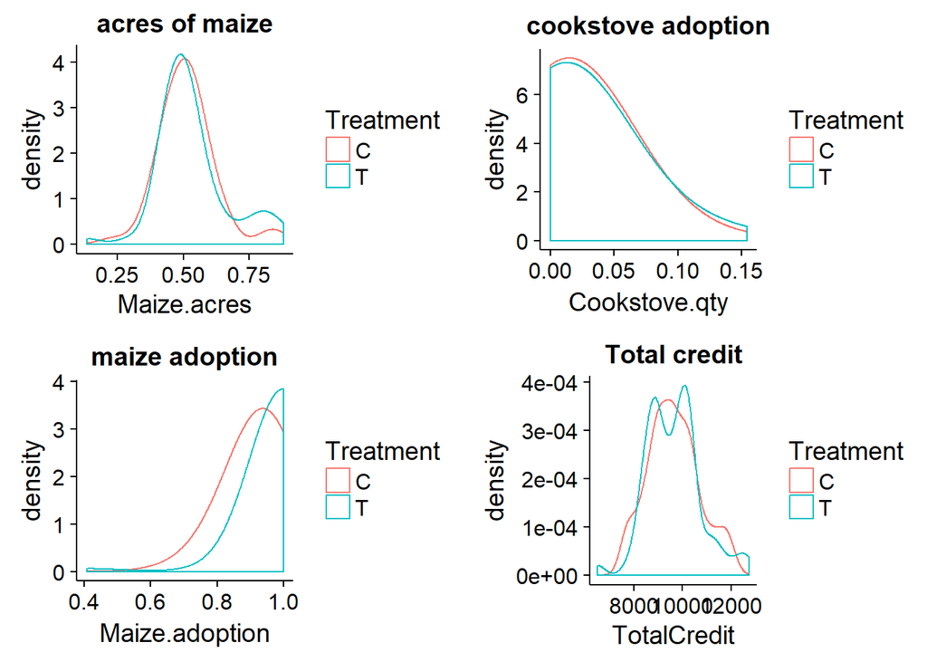

```r
h1 <- ggplot(sdat, aes(x=Maize.acres,color=Treatment)) + geom_density(bw=0.05) +ggtitle("acres of maize")
h2 <- ggplot(sdat, aes(x=Maize.adoption,color=Treatment)) + geom_density(bw=0.1) +ggtitle("maize adoption")
h3 <- ggplot(sdat, aes(x=Cookstove.qty,color=Treatment)) + geom_density(bw=0.05) +ggtitle("cookstove adoption")
h4 <- ggplot(sdat, aes(x=TotalCredit,color=Treatment)) + geom_density(bw=300) +ggtitle("Total credit")

#qq=qqnorm(supdat$TotalCredit, plot.it=FALSE)
multiplot(h1,h2,h3,h4,  cols=2)
```

From these graphs we can quickly see two things:

- most of the data looks non-normal (see [AMP lesson 1](https://michael-bar.github.io/AMP-lessons/AMP-1-distributions.html#13_distributions_and_metrics) for a refresher)
- Treatment vs. Control differences look to be quite small (except perhaps maize adoption).

At this point we have re-worked our hypotheses into an appropriate PICOT format, summarized the data and examined the underlying distributions to aid our understanding of appropriate next steps. Let’s now take a quick detour to refresh our hypothesis testing understanding and introduce a couple of new concepts.

## 2.4 Theory refresher: Hypothesis testing

We have covered a few aspects of hypothesis testing already in AMP lessons 1 and 2, the key ideas to remember are:

- A P-value of 0.05 means there is a 5% probability that our data (or more extreme data) could have been generated purely by chance
- This means that if we compared two samples from a *single* population 100 times, we would expect to find 5 occasions where the differences looked significant (even though they were not).
- This also means that if we test 20 hypothesis on two samples from a *single* population, then purely by chance one of those hypotheses will appear significant. Thus, it is important to limit the number of hypotheses tested in any experiment (we will be looking at other ways to correct this phenomenon in later lessons).
- Hypothesis tests are exquisitely sensitive to the underlying data distribution
- different hypothesis tests are suited to different uses

Hypothesis tests will generally be either “one sample” or “two-sample” tests. A one sample hypothesis test is used (unsurprisingly) for testing a single sample, such as an observed mean against a “true” (or theoretical) mean. A two-sample test is used for testing two **independent** samples once.

Tests can also be “one-tailed” or “two-tailed”. A one tailed test requires an assumption about directionality, we are essentially saying “test that X is larger than Y” or “test that X is less than Y” (depending on whether the tail is specified as greater-than or lesser-than, respectively). This compares to a two-tailed test where we make no assumption about directionality. This means each hypothesis can take one of four forms:

- H0: $\mu$<sub>1</sub> = $\mu$<sub>2</sub>
- H1: $\mu$<sub>1</sub> != $\mu$<sub>2</sub>
- H1: $\mu$<sub>1</sub> > $\mu$<sub>2</sub>
- H1: $\mu$<sub>1</sub> < $\mu$<sub>2</sub>

H0 is our null hypothesis formulation, whilst H1-H3 specify the test tails.

We can demonstrate the advantages and dis-advantages of the one-tailed test over the two-tailed test below with some simulated data:

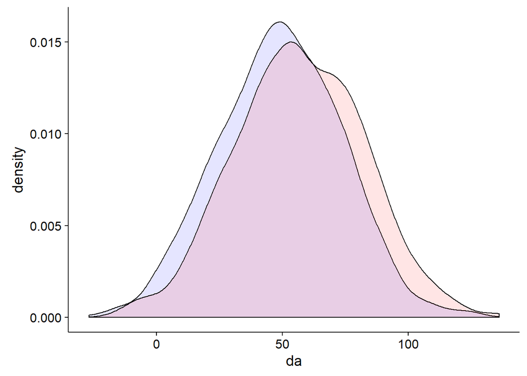

```r
#fake some data
set.seed(999)
da <- rnorm(1000,50,25)
db <- rnorm(1000,56,25)

#plot data
library(ggplot2, quietly = TRUE)

ggplot() + geom_density(aes(da), alpha=0.1, fill="blue") + geom_density(aes(db), alpha=0.1, fill="red")
```

As the data is normally distributed with equal variance we can use either the t-test or the Welch test. Running a two-sided Welch test will confirm the differences in these distributions with a low p-value:

```r
t.test(da,db, alternative="two.sided")
```

```
    Welch Two Sample t-test

data:  da and db
t = -6.9159, df = 1994.5, p-value = 6.239e-12
alternative hypothesis: true difference in means is not equal to 0
95 percent confidence interval:
 -9.936525 -5.546082
sample estimates:
mean of x mean of y
  49.1871   56.9284
```

If we run a one sided test, specified as *less-than* (i.e. $\mu$<sub>1</sub> < $\mu$<sub>2</sub> ), we will also confirm this (note the lower P-value produced):

```r
t.test(da,db, alternative="less")
```

```
    Welch Two Sample t-test

data:  da and db
t = -6.9159, df = 1994.5, p-value = 3.119e-12
alternative hypothesis: true difference in means is less than 0
95 percent confidence interval:
      -Inf -5.899278
sample estimates:
mean of x mean of y
  49.1871   56.9284
```

However, if we run a *greater-than* one-sided test then we will see that we detect no significant difference:

```r
t.test(da,db, alternative="greater")
```

```
    Welch Two Sample t-test

data:  da and db
t = -6.9159, df = 1994.5, p-value = 1
alternative hypothesis: true difference in means is greater than 0
95 percent confidence interval:
 -9.583329       Inf
sample estimates:
mean of x mean of y
  49.1871   56.9284
```

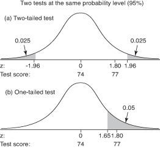

```r
knitr::include_graphics("./one_two_tailed.png")
```

Note that you cannot merely apply a one-sided test twice (once in each direction) as then you are essentially setting your P-value threshold to 2*alpha (e.g. 0.1, rather than 0.05, in the above example).

## 2.5 Theory refresher: which hypothesis test?

Let’s briefly re-visit some of the tests we have covered so far (we will cover tests involving binary or categorical variables in lesson 3):

- Two-sample T-test - this will test for equivalence of means. It assumes that data is normal-like and that both samples have equal variance (see lesson 1)
- Two sample Welch test - this will test for equivalence of means. It requires normal-like distributions but variances can be different (see lesson 1).
- Two-sample Wilcoxon test (aka Mann-Whitney U test) - this will test for similarity of medians. It requires independent samples but does not require normality (see lesson 1). Note that the Wilcoxon test is also suitable for coded ordinal data.
- One-Sample Shapiro test - a test for normality on one sample. Specifically we are testing the null hypothesis that the data is from a normal distribution.

Either the Wilcoxon test or Welch test will be appropriate for OAF data in 95% of cases, notable exceptions are:

- testing time-series data, as these are not independent. e.g. testing whether monthly values over a year from 100 farmers are similar to another 100 farmers. It *is* fine to test end-points, e.g. what is end-of season repayment for treatment and control groups
- Discrete variables (e.g. answers that are Y/N or which have no clear ranking) cannot be tested with any of these tests (see lesson 3 instead). *Ordinal* data can be used with the Wilcoxon test (the [Likert scale](https://en.wikipedia.org/wiki/Likert_scale) is a common example of Ordinal data)
- IID violations. IID stands for independent and identically distributed. Many hypothesis tests assume IID, which is to say that *each event recorded is independent of other events*. For example rolling a six on a dice is independent of whatever I rolled previously, however independence is commonly violated by time-series data (as above) and in clustered data (meaning many hypothesis tests are unsuitable for clustered data analysis).

We will explore time-series data analysis in later lessons (if this is something of interest to you then please email Mike.Barber@ so I can get an idea of how important a task this is).

You can review [AMP lesson 1](https://michael-bar.github.io/AMP-lessons/AMP-1-distributions.html#14_hypothesis_testing) for more details on these hypothesis tests.

## 2.6 Practical: hypothesis testing non-compulsory maize

Let’s now return to hypothesis testing our non-compulsory maize data set.

Remember the earlier plots of cookstove adoption, maize acres, maize adoption and total credit (loan size):

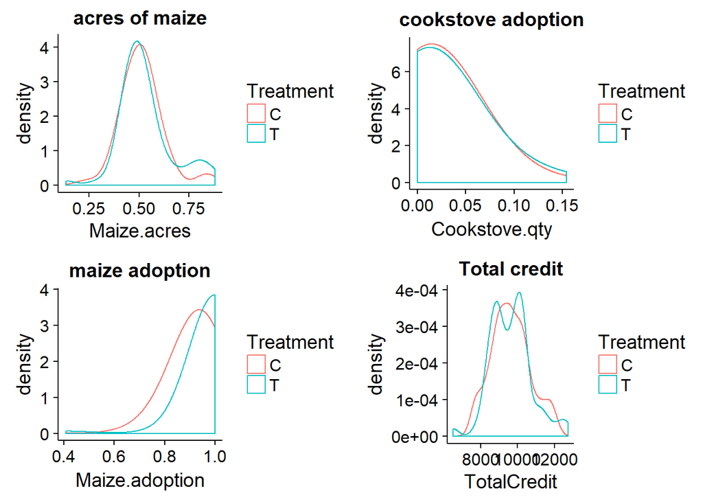

```r
h1 <- ggplot(sdat, aes(x=Maize.acres,color=Treatment)) + geom_density(bw=0.05) +ggtitle("acres of maize")



h2 <- ggplot(sdat, aes(x=Maize.adoption,color=Treatment)) + geom_density(bw=0.1) +ggtitle("maize adoption")

h3 <- ggplot(sdat, aes(x=Cookstove.qty,color=Treatment)) + geom_density(bw=0.05) +ggtitle("cookstove adoption")
h4 <- ggplot(sdat, aes(x=TotalCredit,color=Treatment)) + geom_density(bw=300) +ggtitle("Total credit")

#qq=qqnorm(supdat$TotalCredit, plot.it=FALSE)
multiplot(h1,h2,h3,h4,  cols=2)
```

We previously commented that these look non-normal, let’s test this with the [Shapiro test](https://en.wikipedia.org/wiki/Shapiro%E2%80%93Wilk_test) (and our usual 0.1 p-value threshold for this test):

```r
shapiro.test( subset(sdat, Treatment=="T")$TotalCredit)
```

```
    Shapiro-Wilk normality test

data:  subset(sdat, Treatment == "T")$TotalCredit
W = 0.96708, p-value = 0.07286
```

```r
shapiro.test( subset(sdat, Treatment=="T")$Maize.acres)
```

```
    Shapiro-Wilk normality test

data:  subset(sdat, Treatment == "T")$Maize.acres
W = 0.89203, p-value = 2.772e-05
```

```r
shapiro.test( subset(sdat, Treatment=="T")$Cookstove.qty)
```

```
    Shapiro-Wilk normality test

data:  subset(sdat, Treatment == "T")$Cookstove.qty
W = 0.58759, p-value = 1.982e-12
```

```r
shapiro.test( subset(sdat, Treatment=="T")$Maize.adoption)
```

```
    Shapiro-Wilk normality test

data:  subset(sdat, Treatment == "T")$Maize.adoption
W = 0.19004, p-value < 2.2e-16
```

These all fall below our 0.1 threshold, which means we *reject that they are normally distributed*. We can now apply an appropriate (e.g. non parametric) hypothesis test to this data (alternatively, we could also transform the data to normality and then test it with a parametric method).

The aim of good data presentation should be to convey information accurately, yet succinctly. We can achieve this with some annotated bar graphs displaying the treatment and control means, errors, powers and p-values:

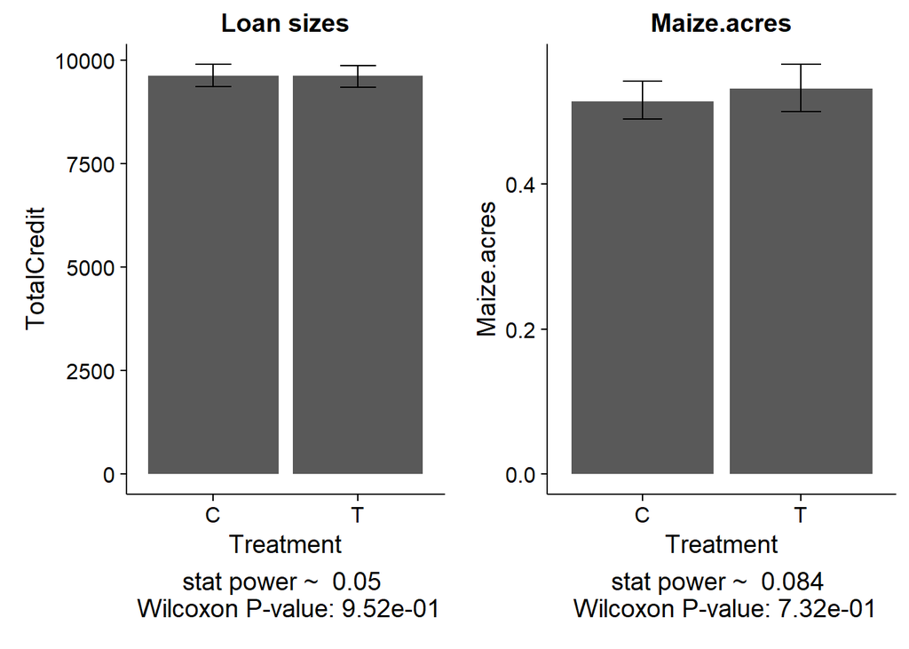

```r
# remember this?
MCpower = function(sample1, sample2, size) {

  reps = 1000
    results  <- sapply(1:reps, function(r) {
        resample1 <- sample(sample1, size=size, replace=TRUE)
        resample2 <- sample(sample2, size=size, replace=TRUE)
        test <- wilcox.test(resample1, resample2, alternative="two.sided",paired=FALSE, correct=TRUE)
        test$p.value
    })
    sum(results<0.05)/reps
}




# plot

library(Hmisc, quietly = TRUE)
#loan size
t <- "TotalCredit"
tp <- MCpower( subset(sdat,Treatment=="T")[[t]] , subset(sdat,Treatment=="C")[[t]] , size= length(subset(sdat, Treatment=="C")[[t]] ))

g1 <- ggplot(sdat, aes(Treatment,TotalCredit))  +
    stat_summary(fun.y = mean, geom = "bar") +
     stat_summary(fun.data = mean_cl_boot, geom = "errorbar", width=0.25) +
      ggtitle("Loan sizes")

g1 <- add_sub(g1, paste("stat power ~ ",round(tp,3),"\n","Wilcoxon P-value:",format(wilcox.test(subset(sdat, Treatment=="C")[[t]], subset(sdat, Treatment=="T")[[t]]  ,paired=FALSE, correct=TRUE)$p.value,scientific = TRUE,digits=3) ))


#maize acres
t <- "Maize.acres"
tp <- MCpower( subset(sdat,Treatment=="T")[[t]] , subset(sdat,Treatment=="C")[[t]] , size= length(subset(sdat, Treatment=="C")[[t]] ))

g2 <- ggplot(sdat, aes(Treatment,Maize.acres)) + stat_summary(fun.y = mean, geom = "bar") + stat_summary(fun.data = mean_cl_boot, geom = "errorbar", width=0.25) + ggtitle("Maize.acres")
g2 <- add_sub(g2, paste("stat power ~ ",round(tp,3),"\n","Wilcoxon P-value:",format(wilcox.test(subset(sdat, Treatment=="C")[[t]], subset(sdat, Treatment=="T")[[t]]  ,paired=FALSE, correct=TRUE)$p.value,scientific = TRUE,digits=3) ))

#maize adoption
t <- "Maize.adoption"
tp <- MCpower( subset(sdat,Treatment=="T")[[t]] , subset(sdat,Treatment=="C")[[t]] , size= length(subset(sdat, Treatment=="C")[[t]] ))

g3 <- ggplot(sdat, aes(Treatment,Maize.adoption)) + stat_summary(fun.y = mean, geom = "bar") + stat_summary(fun.data = mean_cl_boot, geom = "errorbar", width=0.25) + ggtitle("Maize.adoption")
g3 <- add_sub(g3, paste("stat power ~ ",round(tp,3),"\n","Wilcoxon P-value:",format(wilcox.test(subset(sdat, Treatment=="C")[[t]], subset(sdat, Treatment=="T")[[t]]  ,paired=FALSE, correct=TRUE)$p.value,scientific = TRUE,digits=3) ))
#cookstove qty
t <- "Cookstove.qty"
tp <- MCpower( subset(sdat,Treatment=="T")[[t]] , subset(sdat,Treatment=="C")[[t]] , size= length(subset(sdat, Treatment=="C")[[t]] ))

g4 <- ggplot(sdat, aes(Treatment,Cookstove.qty)) + stat_summary(fun.y = mean, geom = "bar") + stat_summary(fun.data = mean_cl_boot, geom = "errorbar", width=0.25) + ggtitle("Cookstove.qty")
g4 <- add_sub(g4, paste("stat power ~ ",round(tp,3),"\n","Wilcoxon P-value:",format(wilcox.test(subset(sdat, Treatment=="C")[[t]], subset(sdat, Treatment=="T")[[t]]  ,paired=FALSE, correct=TRUE)$p.value,scientific = TRUE,digits=3) ))

#assemble
library(cowplot, quietly = TRUE)
plot_grid(g1,g2,ncol =2, nrow = 1)
```

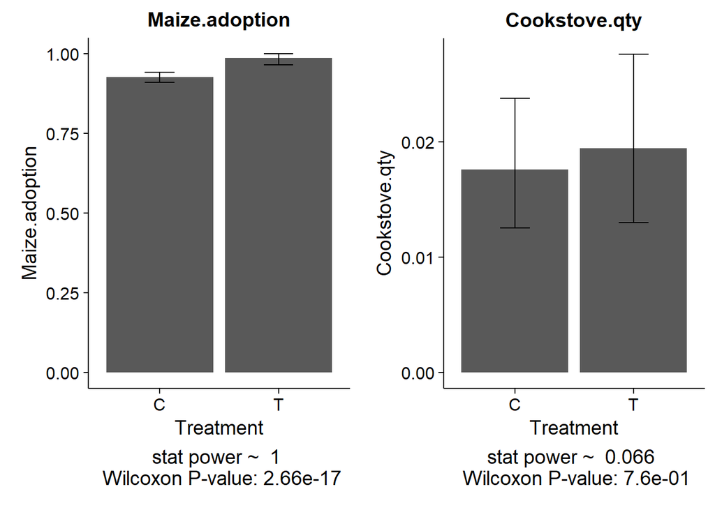

```r
plot_grid(g3,g4 , ncol = 2, nrow = 1)
```

Note that I’ve made a simple function (`nicebars`) that will produce graphs similar to those above, I recommend you use this function in presenting your own data:

```r
nicebars <- function(varname, dataframe1, treatname){


  dataframe1$temp = unlist(dataframe1[varname])

    dataframe1$treated = unlist(dataframe1[treatname])
  t1 =  unique(dataframe1$treated)[1]
  t2 =  unique(dataframe1$treated)[2]

  colnames(dataframe1)[which(colnames(dataframe1)==treatname)] = "treatname"
  tp = MCpower( subset(dataframe1,treated==t1)$temp , subset(dataframe1,treated==t2)$temp , size= length(subset(dataframe1, treated==t2)$temp ))



  gx = ggplot(dataframe1, aes(treatname,temp)) + stat_summary(fun.y = mean, geom = "bar") + stat_summary(fun.data = mean_cl_boot, geom = "errorbar", width=0.25) + ggtitle(varname)
  gx = add_sub(gx, paste("stat power ~ ",round(tp,3),"\n","Wilcoxon P-value:",format(wilcox.test(subset(dataframe1, treated==t1)$temp, subset(dataframe1, treated==t2)$temp  ,paired=FALSE, correct=TRUE, exact=FALSE)$p.value,scientific = TRUE,digits=3) ))
  library(cowplot)
plot_grid(gx,ncol =1, nrow = 1)
}

# nicebars("Cookstove.qty", sdat, "Treatment")
```

`nicebars` requires three arguments:

- `varname` - the name of the variable you want to plot
- `dataframe1` - the dataframe to plot from
- `treatname` - the variable indicating treatment/control

And is called like this `nicebars("Cookstove.qty", sdat, "Treatment")`.

We can see from the above that 3/4 of our hypothesis are significantly under-powered (refresh your [power understanding](https://michael-bar.github.io/AMP-lessons/AMP-1-distributions.html#15_statistical_power_and_sample_size_calculation)). We can use the MDE concept introduced in AMP lesson 2 to understand the effect size we would need to achieve a power of 0.8 with our current sample size:

```r
posthoc_mde = function(d1,d2){

  require(pwr)

  #print(paste("mean diff (d2-d1)", mean(d2, na.rm=TRUE)-mean(d1,na.rm=TRUE)))
  s1= sd(d1,na.rm=TRUE)
  s2=sd(d2,na.rm=TRUE)
  spo = sqrt((s1**2 + s2**2)/2)
  mded = pwr.t.test(n = length(d1), d=NULL, sig.level = 0.05, power=0.8, type="two.sample", alternative = "two.sided")$d
  mde_out = mded * spo
  return(mde_out)
}

mde1 = round(posthoc_mde(subset(sdat, Treatment=="T")$Maize.adoption, subset(sdat, Treatment=="C")$Maize.adoption),3)
mde2 = round(posthoc_mde(subset(sdat, Treatment=="T")$TotalCredit, subset(sdat, Treatment=="C")$TotalCredit),3)
mde3 = round(posthoc_mde(subset(sdat, Treatment=="T")$Maize.acres, subset(sdat, Treatment=="C")$Maize.acres),3)
mde4 = round(posthoc_mde(subset(sdat, Treatment=="T")$Cookstove.qty, subset(sdat, Treatment=="C")$Cookstove.qty),3)

ac1 = round(mean(subset(sdat, Treatment=="T")$Maize.adoption, na.rm=TRUE) - mean(subset(sdat, Treatment=="C")$Maize.adoption, na.rm=TRUE),3)
ac2 = round(mean(subset(sdat, Treatment=="T")$TotalCredit, na.rm=TRUE) - mean(subset(sdat, Treatment=="C")$TotalCredit,na.rm=TRUE),3)
ac3 = round(mean(subset(sdat, Treatment=="T")$Maize.acres,na.rm=TRUE) - mean(subset(sdat, Treatment=="C")$Maize.acres, na.rm=TRUE),3)
ac4 = round(mean(subset(sdat, Treatment=="T")$Cookstove.qty,na.rm=TRUE) - mean(subset(sdat, Treatment=="C")$Cookstove.qty, na.rm=TRUE),3)
```

From the above, we can report the MDE (at 0.8 power), and the actual measured effect, for each hypothesis:

- H1 maize adoption (measured as average maize acres per site):
  - MDE(0.8) = 0.06
  - actual = 0.018 additional acres
- H2 maize adoption (measured as and the percent of farmers who chose to purchase any maize in a site),
  - MDE(0.8) = 3.5 % pts
  - actual = 6 % pts
- H3 transaction size (measured as the average client loan size per site),
  - MDE(0.8) = 534.799 Kenyan Shillings
  - actual = 6.297 Kenyan shillings (~100 KES = 1USD)
- H4 cookstove adoption (measured as the percentage of farmers with 1+ cookstoves per site),
  - MDE(0.8) = 1.3 % pts
  - actual = 0.2 % pts

This means that with our current set up, we would need to have effects equal to, or larger than, those listed above to achieve a power of 0.8. We can also say that we are fairly confident that the **true** effects do not exceed the values above, or we would have had an 80% probability of detecting them.

### 2.6.1 Interpreting hypothesis tests

I want you now to take a moment and think about the results above, specifically:

- What are the error bars showing?
- What does the height of the bar represent?
- What does is mean to have a `stat power` of 0.1, or 0.7 ?
- What does is mean to have a p-value of 0.1 (aka 1e-01)?
- What do the MDE values mean?

Think about these concepts in relation to each of the 4 hypotheses outlined above, and decide what conclusions you **can** and **cannot** draw. This exercise will form part of the homework assignment for this lesson, please note your conclusions and book an office hours slot with me to discuss them (alternatively, as a second-preference option, you can email me the conclusions at Mike.Barber@).

## 2.7 Summary

- We can use hypothesis tests and power calculations in an RCT to draw conclusions about our hypotheses.
- There is no one-size fits all hypothesis test, chose the appropriate test wisely!
- MDEs allow us to understand what effect size we would need to have sufficient power
- Remember that in an RCT, as long as our treatment and control groups are balanced, then these simple hypothesis tests will tell us all we need to know about a study. Our regression results should not differ from these tests, if they do then it suggests something is a-miss!
- We use different hypothesis tests under different environments, remember which test to use when!

# 3 Theory: Regressing independent data

Up to this point we’ve scrutinized the data and executed initial hypothesis tests to understand effect sizes and statistical power. We’ll now turn to the second major tool in the analyst’s tool set: **linear regressions**.

To run a linear regression is simple. Just `lm(x,y)` and hey-presto, results! Easy, right?

Well yes, and no. Linear regressions have a set of **assumptions** and **caveats** associated with them which need to be checked before we interpret the regression results. If we violate these assumptions then the code *will still run*, and you will still get co-efficients and p-values (etc), but they will likely be *meaningless!* This means that a bad linear regression can result in recommending interventions which actually have **no** effect, or missing interventions which **do** have an effect.

> A little statistics can be a dangerous thing!

## 3.1 Criteria for a good model

We will here define a good model according to the following criteria:

- model is capable of explaining/predicting the full range of Y values
- model can accurately provide confidence intervals to inform our understanding of uncertainty (and significance)
- model is not distorted by outliers

We can satisfy these requirements by fulfilling the following criteria:

- the relationship between X and Y is linear
- Errors are independent of X (a.k.a. homoskedascity)
- variables are mostly un-correlated with each other
- Residuals are normally distributed

Therefore, to build a good model, we will need to understand and evaluate the underlying assumptions outlined above. We will do this through a series of plots that examine a number of things, but perhaps most importantly, the **residuals** of a model:

- A **residual** is the difference between a model prediction and an actually observed value.

We will explore these plots first with a well-behaved regression, to understand how plots look in a best-case scenario, and then how these plots react to heteroskedascity and non-linearity.

## 3.2 Theory: A well-behaved regression

First, a well behaved regression model. We will (hopefully) remember the definition of a straight line:

$Y= \beta . X + c$ - where $c$ is our intercept and $\beta$ our coefficient

We will use this equation to understand regression, with the addition of an $e$ term to represent the independent error around our mean. When running a regression, our aim is to determine:

$Y= \beta . X + c + e$

so that we can *accurately* determine the size of coefficient $\beta$ (and so our treatment effect) and $e$ (so we can determine its significance).

Let’s use a worked example to demonstrate how regression works. First, let us define our relationship (with the aim of recovering these values from the regression results):

- Intercept = $10$
- $\beta$ = $2$
- Error term = $= 3 $

We’ll simulate 200 independent values based on this equation now:

```r
set.seed(111)
ex1 <- data.frame("Xvals"=runif(1:200, min=1,max=10) )
ex1$Yvals = 10 + 2*ex1$Xvals + rnorm(200,0,3) # y = \beta . X +c +e

head(ex1[c("Xvals","Yvals")])
```

```
##      Xvals    Yvals
## 1 6.336832 24.47252
## 2 7.538330 21.59567
## 3 4.333798 19.98488
## 4 5.634314 21.88319
## 5 4.398969 16.70039
## 6 4.765036 16.75019
```

Let’s now regress Xvals against Yvals, to ask: “what correlation is there between Xvals and Yvals?”.

```r
exreg1 <- lm(Yvals~Xvals, data=ex1)
```

As our regression is relatively simple, with only one independent variable, we can easily visualize the results with a simple plot:

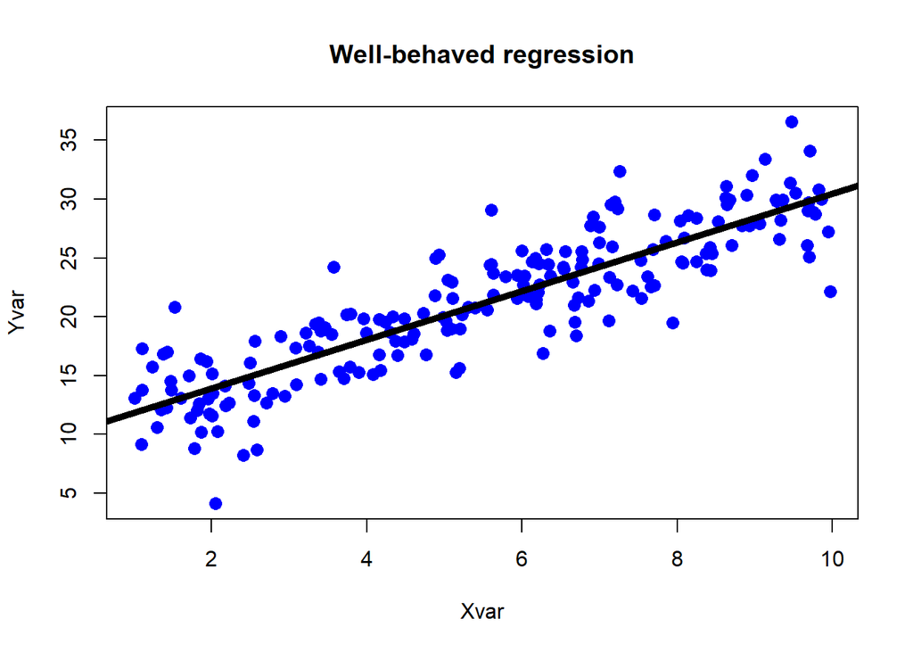

```r
plot(ex1$Xvals, ex1$Yvals,  pch = 16, cex = 1.3, col = "blue", main = "Well-behaved regression", xlab="Xvar", ylab="Yvar")
abline(exreg1, lw=5)
```

We can see the black line does a good job of describing the relationship between `Xvals` and `Yvals`. Also note that the blue points are relatively equi-distant from the regression line; this is something we care about a lot about in regression analysis. The distance from each point (blue) to the model (black line) is known as the *residual*, we will collect these together (pl. *residuals*) to understand our model performance (below).

Before analyzing model residuals, let’s quickly examine the regression summary:

```r
library(stargazer)
stargazer(exreg1, type = "html",style="all", title="well-behaved regression example 1",notes="", notes.append=FALSE,star.char="", omit.table.layout = "na")
```

**well-behaved regression example 1**

|  | *Dependent variable:* |
| --- | --- |
|  | Yvals |
| Xvals | 2.071 |
|  | (0.080) |
|  | t = 25.906 |
|  | p = 0.000 |
| Constant | 9.786 |
|  | (0.489) |
|  | t = 20.019 |
|  | p = 0.000 |
| Observations | 200 |
| R<sup>2</sup> | 0.772 |
| Adjusted R<sup>2</sup> | 0.771 |
| Residual Std. Error | 2.911 (df = 198) |
| F Statistic | 671.096 (df = 1; 198) (p = 0.000) |

```r
# summary(exreg1)
```

Let’s refresh what these terms mean before we proceed:

- **P-value**: The [p-value](http://blog.minitab.com/blog/adventures-in-statistics-2/how-to-interpret-regression-analysis-results-p-values-and-coefficients) derives from testing the null hypothesis that *the coefficeint = 0*. If the p-value is below a certain threshold (usually 0.05) then we *reject the null hypothesis* and call the result “significant”. Note that significance in statistics means something like “reliable”. So a coefficient can be very small but still statistically significant (reliable).
- **Coefficient**: Each [coefficient](http://support.minitab.com/en-us/minitab-express/1/help-and-how-to/modeling-statistics/regression/supporting-topics/regression-models/what-is-a-regression-coefficient/) estimates the change in the mean response per unit increase in X when all other predictors are held constant.
- **Constant**: The intercept term in our equation.
- **Observations**: The number of rows in our dataframe.
- **$R^2$** [R-squared](http://blog.minitab.com/blog/adventures-in-statistics-2/regression-analysis-how-do-i-interpret-r-squared-and-assess-the-goodness-of-fit) is a statistical measure of how close the data are to the fitted regression line. It is also known as the coefficient of determination, or the coefficient of multiple determination for multiple regression. R-squared = Explained variation / Total variation. R-squared cannot determine whether the coefficient estimates and predictions are biased, which is why you must assess the residual plots.R-squared does not indicate whether a regression model is adequate. You can have a low R-squared value for a good model, or a high R-squared value for a model that does not fit the data!
- **Adjusted R2** The [adjusted R-squared](http://blog.minitab.com/blog/adventures-in-statistics-2/multiple-regession-analysis-use-adjusted-r-squared-and-predicted-r-squared-to-include-the-correct-number-of-variables) compares the explanatory power of regression models that contain different numbers of predictors. The adjusted R-squared is a modified version of R-squared that has been adjusted for the number of predictors in the model. The adjusted R-squared increases only if the new term improves the model more than would be expected by chance. It decreases when a predictor improves the model by less than expected by chance. The adjusted R-squared can be negative, but it’s usually not. It is always lower than the R-squared.
- **F statistic** Does the addition of variables improve the regression model overall? The F-statistic reports on the null hypothesis that *Our current model is indistinguishable from an intercept-only model*. Rejection of this hypothesis (p<0.05) suggests that the inclusion of variables is helpful.

We can see that we nicely recover the intercept and coefficient terms (plus some confidence intervals proportional to our error term):

- *Intercept* = 9.79
- *$\beta$* = 2.07

Next, let us examine the diagnostic plots to evaluate how the model fulfills the assumptions we stated above:

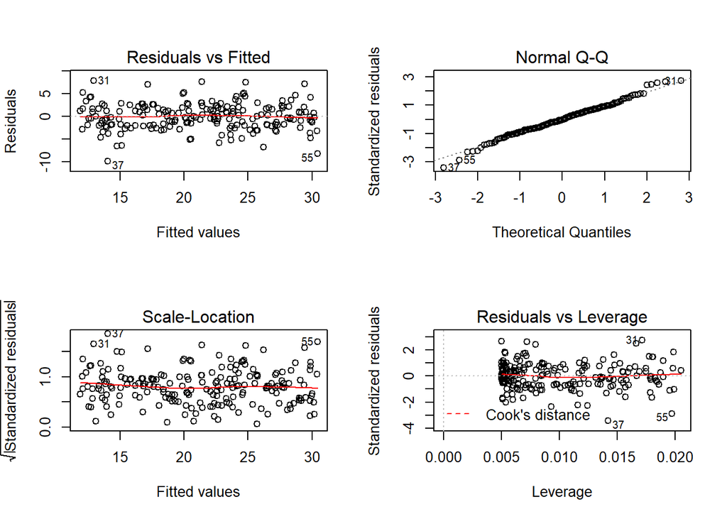

```r
par(mfrow=c(2,2))
plot(exreg1)
```

Let’s take these plots one by one and diagnose them:

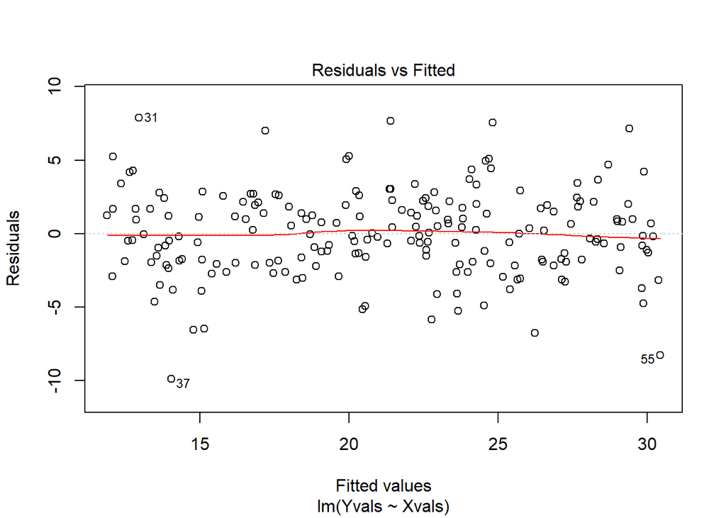

```r
plot(exreg1, which=1)
```

- This plot shows the model residuals vs fitted values. Ideally, we want the residuals to be evenly distributed around the dotted black line at 0. The red line indicates the mean residual value, and ideally would lie on the 0.0 black line
- A non-flat red line indicates that our data may be non-linear (think through why this is, using the “Xvals vs Yvals” graph above).
- Points with un-even or non-symmetrical scatter around the 0.0 line represent either heteroskedascity or non-linearity (again - think through why this is so).
- A nice summary can be seen [here](https://onlinecourses.science.psu.edu/stat501/node/36) ).

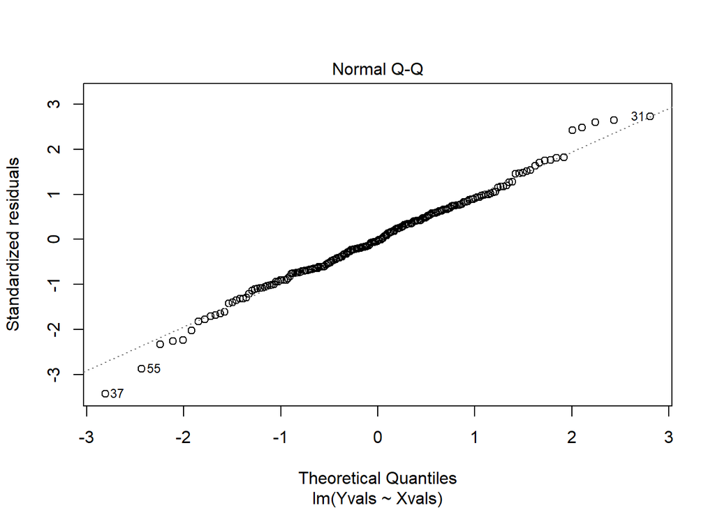

```r
plot(exreg1, which=2)
```

- This is a QQplot of residuals. The presence of trend deviations from the diagonal line (which represents perfect normality) suggest non-normality in our residuals (see [AMP Lesson 1](https://michael-bar.github.io/AMP-lessons/AMP-1-distributions.html#) for more information). We don’t see any trends in our residuals here (the scatter at high and low X is minor and unalarming as it does not constitute a trend).

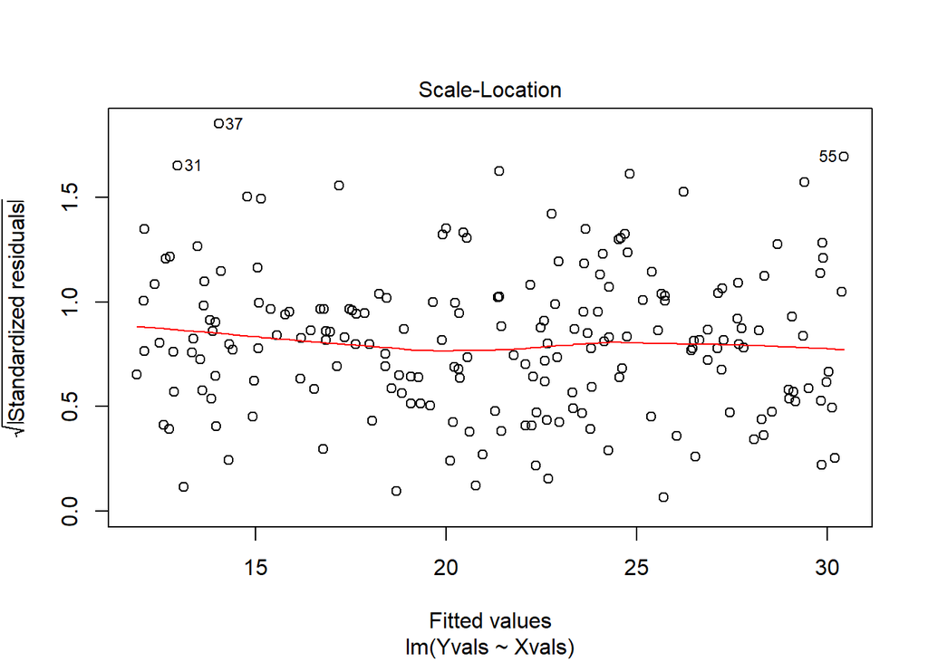

```r
plot(exreg1, which=3)
```

- The scale-location plot shows the square root of the standardized residuals as a function of the fitted values. This is similar to our residuals vs fitted plot above, and should be interpreted similarly.

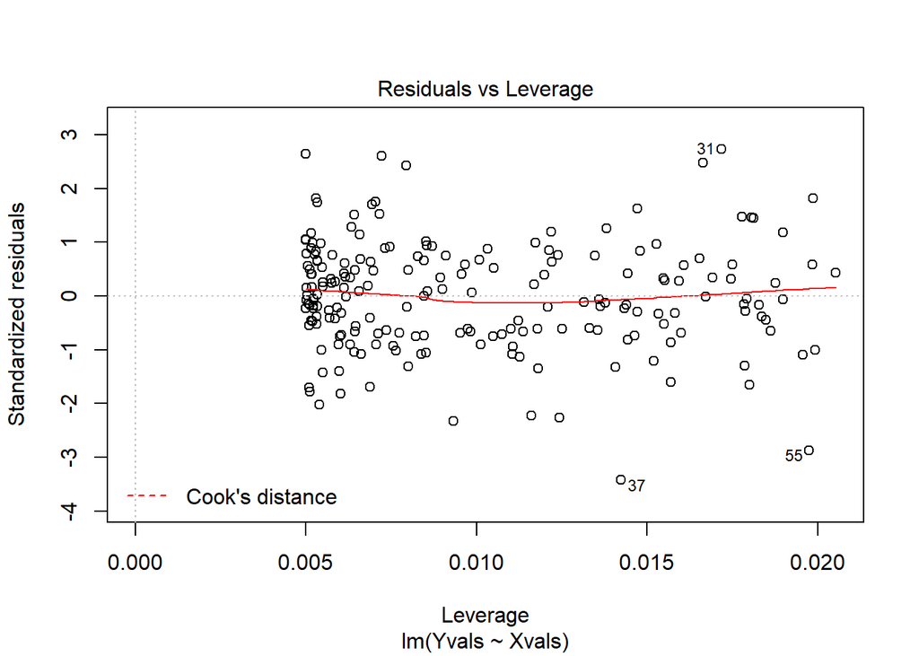

```r
plot(exreg1, which=5)
```

- Finally, the leverage plot measures the impact of each point on our final output vs the residual of that point. Essentially, this graph will aid us is spotting data points that are having an outsize influence on our model. If some points have high leverage *and* a high (absolute) residual value then they will be skewing our model more than other data points. Cook’s distance (the dotted lines) is a measurement combining residual size and leverage.
- Note that we don’t see any Cook’s distance lines on the above as our Cook’s values are too small (this is a good thing!)

Overall, these plots look reasonable, and I am happy that we have satisfied the linear model requirements. Note that we could also use the Shapiro test on the QQplot of residuals to test for normality:

```r
resi1 <- shapiro.test( rstandard(exreg1)) #standardised residuals. i.e. divided by stdev
resi1
```

```
    Shapiro-Wilk normality test

data:  rstandard(exreg1)
W = 0.99115, p-value = 0.2613
```

Our Shapiro test indicates normal residuals.

In summary, this regression looks very valid:

- The residuals vs fitted plot shows a flat, straight line and no obvious pattern in the residuals
- The QQplot of residuals likewise looks reasonable. Whilst we can see a few deviations from the dashed-line, these are not what I would call “trend deviations”. We can use a Shapiro test on the residuals to confirm this (p= 0.2613), though in general I recommend simply examining the QQplot rather than running repeated hypothesis tests.
- Our scale-location plot likewise is flat and without pattern
- Our residuals vs leverage plot does not reveal any clear outliers.

## 3.3 Theory: Non-linear relationships

Let’s now turn to a poorly behaved regression, specifically, we will examine the diagnostic plots produced from a non-linear relationship and compare them to the plots above:

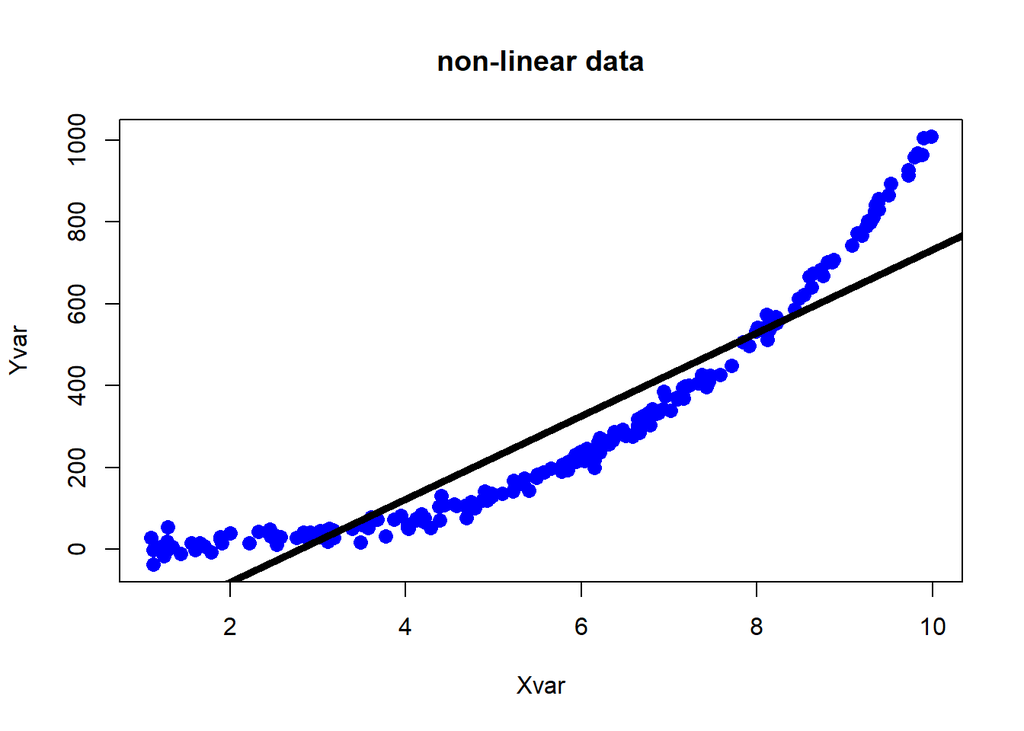

```r
ex2 <- data.frame("Xvals"=runif(1:200, min=1,max=10) )
ex2$Yvals = 10 + ex2$Xvals**3 + rnorm(200,0,15)



plot(ex2$Xvals, ex2$Yvals,  pch = 16, cex = 1.3, col = "blue", main = "non-linear data", xlab="Xvar", ylab="Yvar")
abline(lm(Yvals~ Xvals ,data=ex2), lw=5)
```

Hmm, clearly here we have tried to fit a linear model to a non-linear relationship! This model is therefore useless (remember our definition of a good model from the start of this section). Note, that whilst we can clearly see our model is terrible (i.e. it would do a bad job of predicting Ys given a set of Xs) we are still able to achieve a great R-squared of 0.856. **Do not blindly follow R-squareds into oblivion!**

Let’s look at the diagnostic plots:

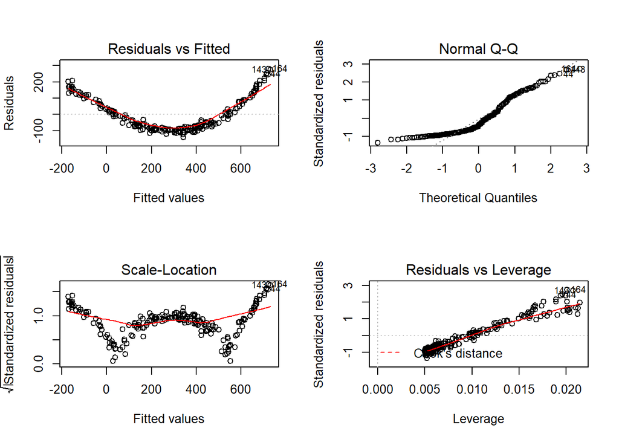

```r
exreg2 <- lm(Yvals~Xvals, data=ex2)



par(mfrow=c(2,2))
plot(exreg2)
```

Compare these plots to the well-behaved regression plots to understand how they vary under non-ideal conditions. Likewise, spend some time trying to understand how these plots related to the simple X-Y plot above.

For example:

- we can note that our residuals cross zero twice in our residuals vs fitted plot, and that our regression line crossed our non-linear data point trend twice also.
- Likewise our scale-location plot
- Note also that our residuals vs leverage plot, we clearly see a trend towards higher leverage and higher residuals (as our data points get further and further from our trend line)

If we examine our QQplot more closely:

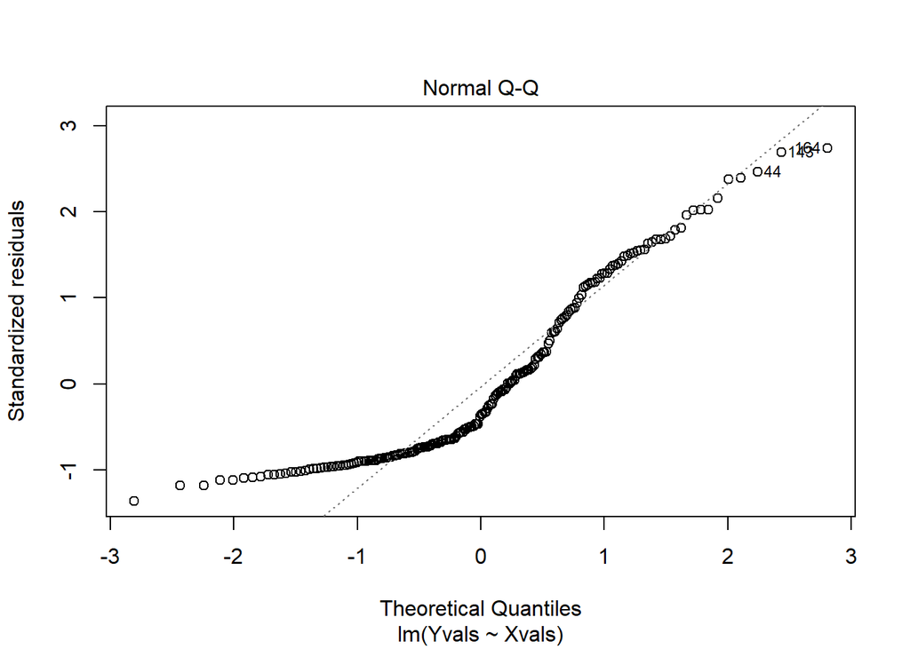

```r
plot(exreg2, which=2)
```

- We’ll note that our residuals plot the trend we would expect from the X-Y plot (that is, the points in the X-Y plot are far from the line, get closer, and then further again).

**Spend some time examining the relationships within these plots to improve your ability to quickly diagnose which linear-model assumption you are violating.**

## 3.4 Theory: Poorly-behaved regression, heteroskedastic data

Finally, let’s look at what extreme heteroskedasticity looks like (remember: heteroskedascity is when our error term is dependent on X):

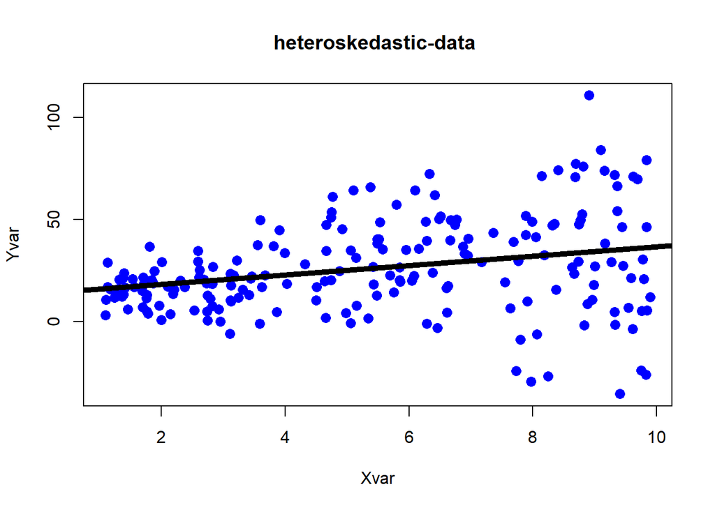

```r
ex3 <- data.frame("Xvals"=runif(1:200, min=1,max=10) )

ex3$Yvals = 10 + 3*ex3$Xvals + rnorm(200,1,1+4*ex3$Xvals)


plot(ex3$Xvals, ex3$Yvals,  pch = 16, cex = 1.3, col = "blue", main = "heteroskedastic-data ", xlab="Xvar", ylab="Yvar")
abline(lm(Yvals~ Xvals ,data=ex3), lw=5)
```

Note the cone-shaped data indicating heteroskedascity.

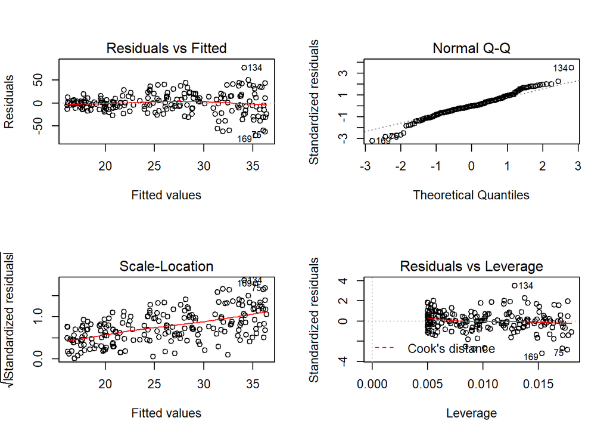

```r
exreg3 <- lm(Yvals~Xvals, data=ex3)

par(mfrow=c(2,2))
plot(exreg3)
```

Again, compare this to our well-behaved regression to understand how heteroskedastic data appears in regression plots (hint: examine the residuals vs fitted plots, and the scale-location plots closely).

**Remember - in a real regression analysis with multiple factors you will not have a simple Xvar-Yvar regression plot to easily diagnose your model, so you will need to be comfortable using these diagnostics alone!**

Finally, I want to introduce a plot that isn’t automatically produced by R, but that is incredibly useful in regression diagnostics. In this graph, we will plot our fitted values vs our real (observed) values to see how the model performs, let’s plot these graphs for the above regression examples:

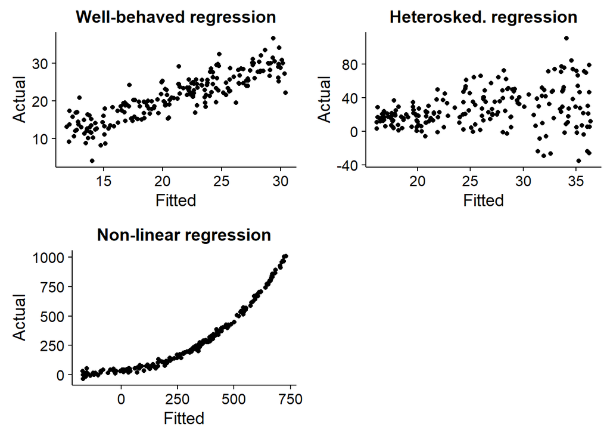

```r
g1 = ggplot() +geom_point(aes(x=predict(exreg1), y=ex1$Yvals)) + xlab("Fitted") + ylab("Actual") + ggtitle("Well-behaved regression")
g2 = ggplot() +geom_point(aes(x=predict(exreg2), y=ex2$Yvals)) + xlab("Fitted") + ylab("Actual") + ggtitle("Non-linear regression")
g3 = ggplot() +geom_point(aes(x=predict(exreg3), y=ex3$Yvals)) + xlab("Fitted") + ylab("Actual") + ggtitle("Heterosked. regression")



multiplot(g1,g2,g3, cols=2)
```

Spend some time examining and understanding these plots, and how these models compare against the criteria we outlined above:

- model is capable of explaining both low and high Y values
- model can accurately provide confidence intervals to inform our understanding of variability (and significance)
- model is not distorted by outliers
- given a set of Xs, our model can accurately predict Ys

## 3.5 Summary:

- Regressions have assumptions that must be met to produce meaningful results
- Diagnostic plots will allow you to assess the extent to which your model is meeting these assumptions
- Always present diagnostic plots for any model you create! You can keep these in an appendix at the end of the document/presentation.

# 4 Theory: data transformations

One of the approaches to improving diagnostic plots for a regression is transforming data. Generally, either X or Y variables will be transformed. We will focus on Y-variable transformations here, as they are much more commonly practiced at One Acre Fund than X transformations.

Common y transformations include:

- $ln$ or $log10$ transformations
- Simple power transformations (square root or squared)

It is commonly assumed that when y-variables are transformed we can merely back-transform (that is, apply the inverse function to) the model coefficients to make them interpretable.

**This is incorrect! Transforming a y-variable with alter the coefficients in more complex ways!**

Generally, back-transforming coefficients for y transformed data will require solving complex differential equations (there is a notable exception here, which is covered later in the lesson), and is not as simple as a back transformation. Let’s demonstrate this by returning to our well-behaved regression:

```r
ex4 <- data.frame("Xvals"=runif(1:200, min=1,max=10) )
ex4$Yvals = 10 + 2*ex4$Xvals + rnorm(200,0,5) # y = \beta . X +c +e

exreg4 <- lm(Yvals ~ Xvals, data=ex4)

stargazer(exreg4, type = "html",style="all")
```

|  | *Dependent variable:* |
| --- | --- |
|  | Yvals |
| Xvals | 2.209*** |
|  | (0.148) |
|  | t = 14.907 |
|  | p = 0.000 |
| Constant | 8.683*** |
|  | (0.951) |
|  | t = 9.135 |
|  | p = 0.000 |
| Observations | 200 |
| R<sup>2</sup> | 0.529 |
| Adjusted R<sup>2</sup> | 0.526 |
| Residual Std. Error | 5.360 (df = 198) |
| F Statistic | 222.225*** (df = 1; 198) (p = 0.000) |
| *Note:* | p<0.1; p<0.05; p<0.01 |

Remember that we calculated Y so that $Y = 10 + 2\beta X + e$ (where e is our error term). We can see this regression nicely returns this to us.

Let’s instead regress against the square root of Y, we can see our diagnostic plots still look reasonable:

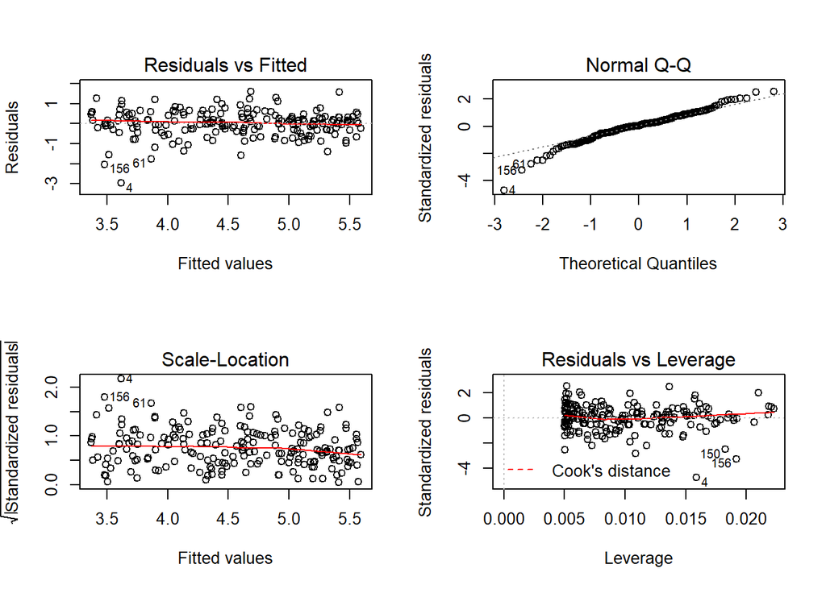

```r
ex4$sqrtY = sqrt(ex4$Yvals)

par(mfrow=c(2,2))
plot(lm(sqrtY ~ Xvals, data=ex4) )
```

And our coefficients:

```r
stargazer( lm(sqrtY ~ Xvals, data=ex4) , type="html")
```

|  | *Dependent variable:* |
| --- | --- |
|  | sqrtY |
| Xvals | 0.253*** |
|  | (0.018) |
| Constant | 3.079*** |
|  | (0.112) |
| Observations | 200 |
| R<sup>2</sup> | 0.513 |
| Adjusted R<sup>2</sup> | 0.511 |
| Residual Std. Error | 0.634 (df = 198) |
| F Statistic | 208.572*** (df = 1; 198) |
| *Note:* | p<0.1; p<0.05; p<0.01 |

This time we get an intercept of 3.0789229 and $\beta$ of 0.253. If we square these (square being the inverse of square root) then we get:

- Intercept = 9.48
- Xvals = 0.064

Clearly, these do not relate to either the original formula or the original regression. Do not make the mistake of blindly back-transforming coefficients!

If transforming variables is necessary, then it is wise to pick a transformation that retains some physical meaning. For example taking the square root of an area (which would yield length). An important danger with transformations is introducing new censures in the data, for example, taking “change in farmer expenditure (USD)” squared would make *all* data positive, and so make model interpretation impossible.

One notable exception to these transformations is the natural-log (in r: `log()`). When Y data is log transformed then coefficients can be interpreted as the % change expected in Y with a one unit increase in X.

## 4.1 Summary

- Do not blindly transform and back-transform data!
- Transformed data often yields un-interpretable coefficients (without solving the appropriate equations)
- Natural-log transformations are an important exception to this rule. ln transformations yield coefficients where a one unit increase in X yields a $\beta *100$ increase in Y.

# 5 Practical: non-compulsory maize regression

Let’s now turn to our real-life One Acre Fund data example, and begin with a really simple regression testing TotalCredit(y) against Maize.adoption (x). This is asking “what correlation is there between maize.adoption and TotalCredit”.

```r
bad_reg <- lm(TotalCredit~ Maize.adoption ,data=sdat)


#this library just makes pretty summaries
library(stargazer, quietly = TRUE)
#I like this layout for regression summaries, feel free to explore the many, many options in stargazer. Alternatively, feel free to just use my line of code here (and swap out "bad_reg" for your regression model varibale)
stargazer(bad_reg, type = "html",style="all", title="Simple regression example 1",notes="", notes.append=FALSE,star.char="", omit.table.layout = "na")
```

**Simple regression example 1**

|  | *Dependent variable:* |
| --- | --- |
|  | TotalCredit |
| Maize.adoption | 4,262.198 |
|  | (1,186.132) |
|  | t = 3.593 |
|  | p = 0.0005 |
| Constant | 5,554.371 |
|  | (1,137.532) |
|  | t = 4.883 |
|  | p = 0.00001 |
| Observations | 133 |
| R<sup>2</sup> | 0.090 |
| Adjusted R<sup>2</sup> | 0.083 |
| Residual Std. Error | 1,046.634 (df = 131) |
| F Statistic | 12.912 (df = 1; 131) (p = 0.0005) |

We can see that we have a large coefficient and a very small p-value, so Maize adoption **seems** to have a large effect on total credit. A solid finding!

… Or perhaps not, let’s dive a little deeper. As we only have two variables in this model (X and Y), we can easily visualize what our regression looks like:

## 5.1 Plotting simple relationships and diagnosing our regression

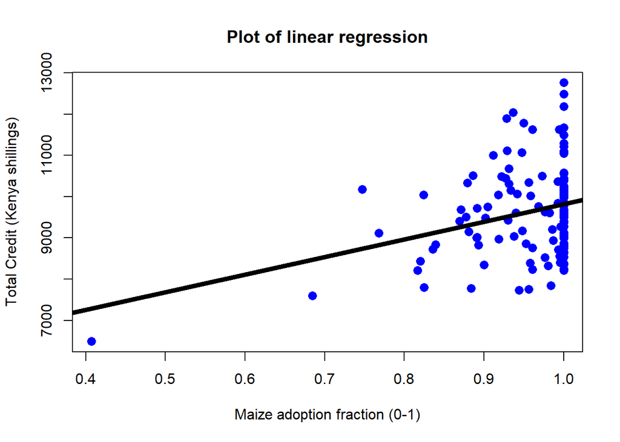

```r
plot(sdat$Maize.adoption, sdat$TotalCredit,  pch = 16, cex = 1.3, col = "blue", main = "Plot of linear regression", xlab="Maize adoption fraction (0-1)", ylab="Total Credit (Kenya shillings)")
abline(lm(TotalCredit~ Maize.adoption ,data=sdat), lw=5)
```

The straight black line represents our model fit. Whilst the points represent the actual data values. Hopefully you can already see that this isn’t looking too healthy (the most obvious flaw from this graph is that most of our points can be found at 1.0 (100%) Maize adoption (i.e. our data is *censured*)). It also looks like our line isn’t quite equi-distant from all our points (i.e. our residuals look unhealthy).

Remember the key requirements of a good model include:

- model is capable of explaining both low and high Y values
- model can accurately provide confidence intervals to inform our understanding of variability
- model is not distorted by outliers
- given a set of Xs, our model can accurately predict Ys

Let’s examine the diagnostic plots for this model to understand to what extent we are meeting these requirements:

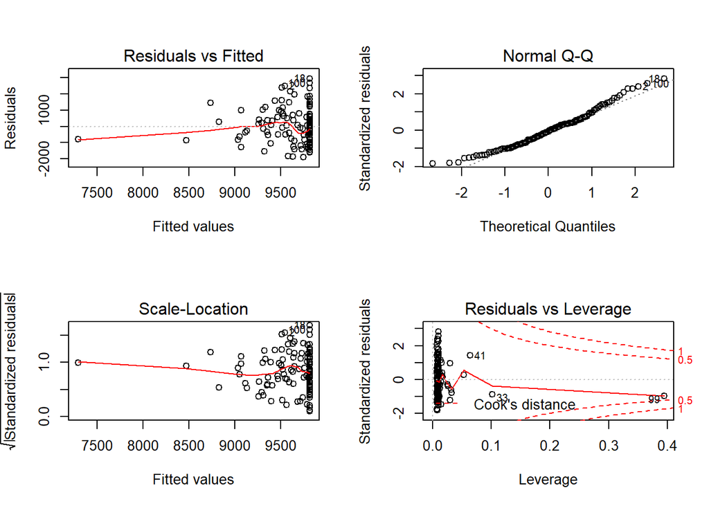

```r
par(mfrow=c(2,2))
plot(bad_reg)
```

Let’s take these plots one by one and diagnose them:

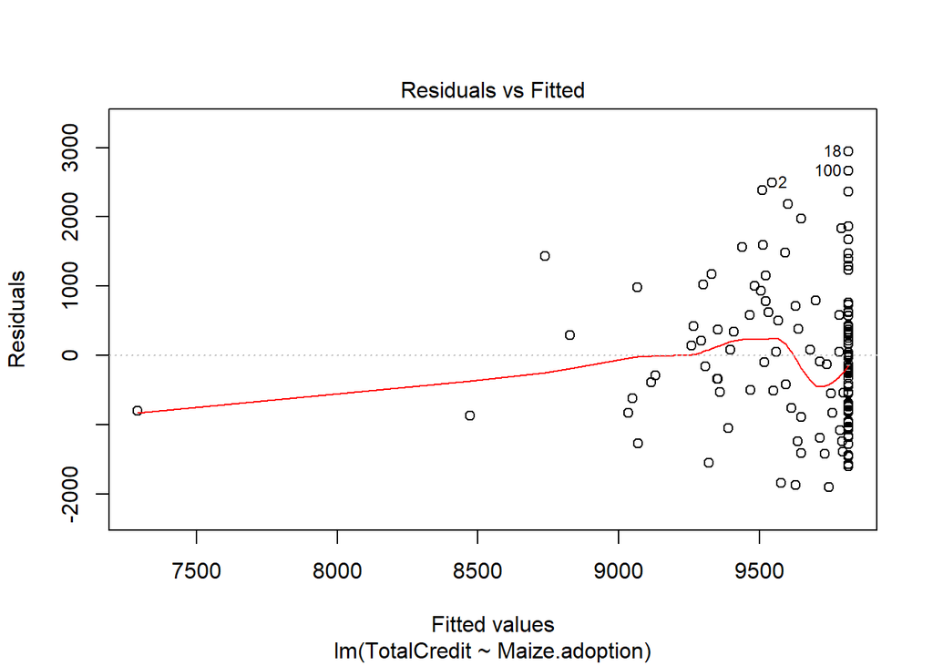

```r
plot(bad_reg, which=1)
```

- For our plot above, the red line is reasonable flat (excluding the left-most point, which is driving the red-line’s trend), but we might have a small relationship between the fitted values and the residuals (i.e. our data might be slightly heteroskedastic).

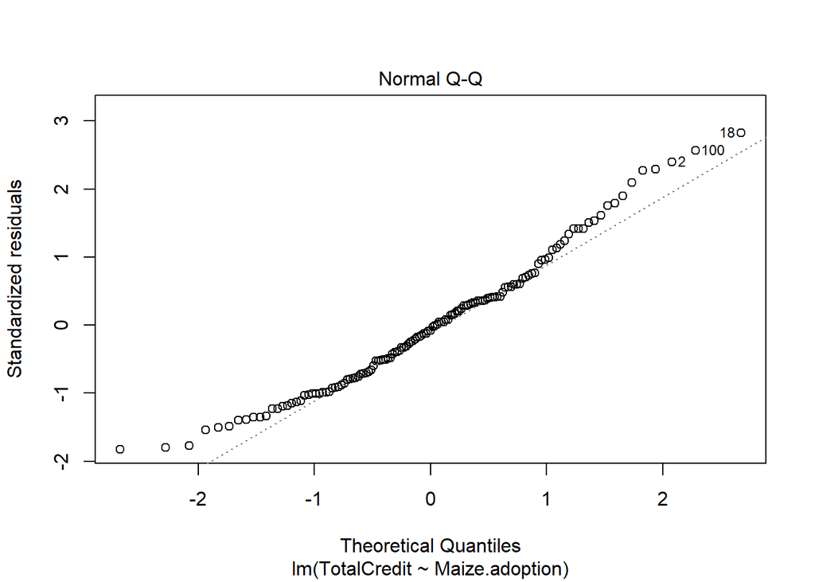

```r
plot(bad_reg, which=2)
```

- For the plot above, we can see trend deviations away from the perfect normal at both high and low quantiles, this suggests our residuals are not normally distributed.

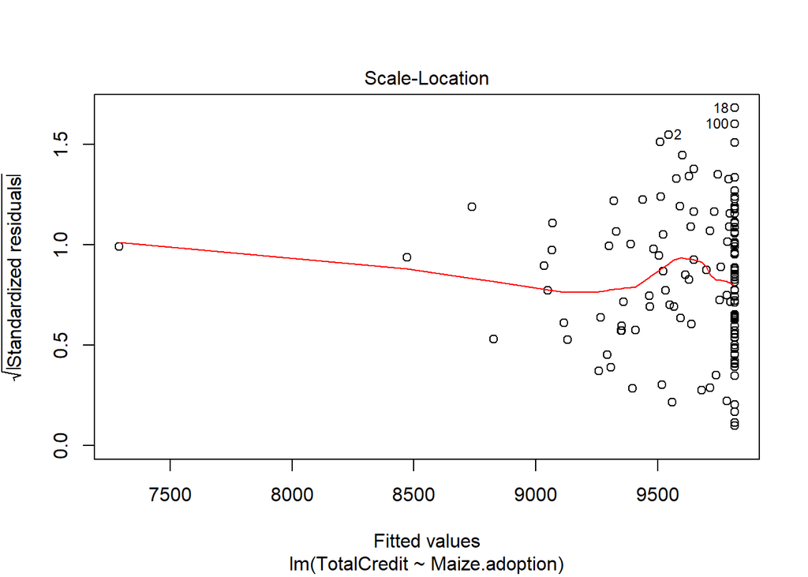

```r
plot(bad_reg, which=3)
```

- Once again, it looks like our residuals depend somewhat on our fitted value (note the cone-like shape of points at the right side of the plot)

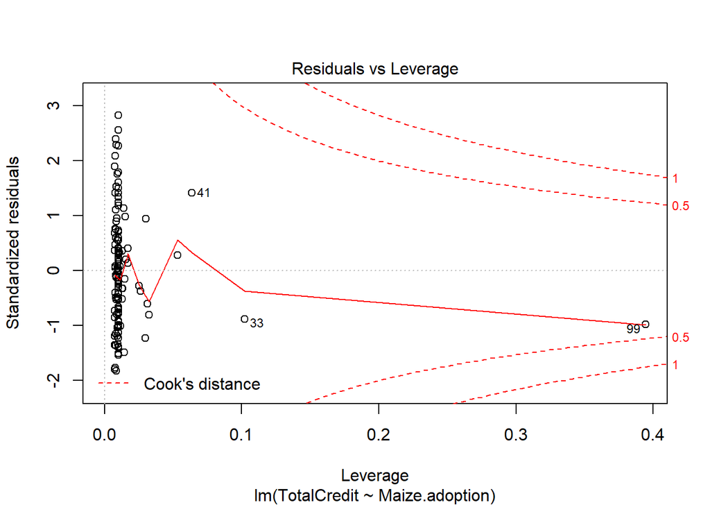

```r
plot(bad_reg, which=5)
```

- Most points are low leverage (and within the Cook’s distance boundaries marked on the plot).
- Point # 99 is a clear outlier with high leverage (although not alarming residuals), a single outlier isn’t too bad (we’ll see how to deal with these below).

**Summarizing the findings from these plots we can say that our current regression suffers from non-normal residuals and slight heteroskedasticity (the leverage plot doesn’t look too bad, as our only outlier has a small residual).**

## 5.2 Practical: Interpreting our regression

Let’s now plot a fitted vs actual graph to gain some insight into model performance:

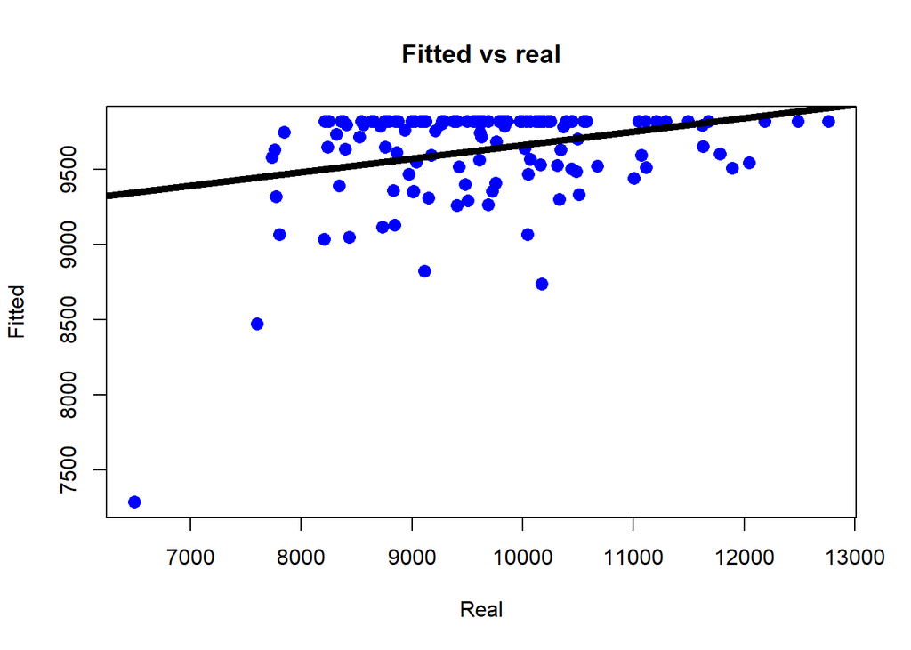

```r
par(mfrow=c(1,1))
#first, lets add a column of fitted values like this
sdat$fitted <- predict(bad_reg)

#let's XY plot them, and then add a new regression line for fitted vs real
plot(sdat$TotalCredit, sdat$fitted,  pch = 16, cex = 1.3, col = "blue", main = "Fitted vs real", xlab="Real", ylab="Fitted")
abline(lm(fitted~ TotalCredit ,data=sdat), lw=5)
```

This plot pretty quickly makes clear that our regression model is useless! Our fitted values occupy a far, far smaller range than our real values, and the model generally fails to predict the “true” values well.

Now let’s revisit our regression results from earlier:

```r
stargazer(bad_reg, type = "html",style="all", title="Simple regression example 1",notes="", notes.append=FALSE,star.char="", omit.table.layout = "na")
```

**Simple regression example 1**

|  | *Dependent variable:* |
| --- | --- |
|  | TotalCredit |
| Maize.adoption | 4,262.198 |
|  | (1,186.132) |
|  | t = 3.593 |
|  | p = 0.0005 |
| Constant | 5,554.371 |
|  | (1,137.532) |
|  | t = 4.883 |
|  | p = 0.00001 |
| Observations | 133 |
| R<sup>2</sup> | 0.090 |
| Adjusted R<sup>2</sup> | 0.083 |
| Residual Std. Error | 1,046.634 (df = 131) |
| F Statistic | 12.912 (df = 1; 131) (p = 0.0005) |

How much do you trust these values now? How willing would you be to stake farmer welfare on these results?

… Maybe we shouldn’t have been so excited after all!

## 5.3 Summary

- Regressions require skill and time! The more regressions you run, the faster you will be at diagnosing (and fixing) them.
- Make sure to check the diagnostic plots for model quality (the 4 from R and the *fitted vs actual* plot)
- It is incredibly important that you start to provide diagnostic plots as standard practice when sharing/publishing **any** and **all** One Acre Fund results! Without these plots I (and future analysts) cannot understand the robustness of your work. Providing all the diagnostic plots (and decisions) will ensure that your work can be used years down the line!
- 95% of One Acre Fund analyses I have seen fail to report any diagnostic plots. Such analyses are useless for decision making, and represent a significant investment in time by an analyst that is subsequently wasted.
- Also note, it is a common **false assumption** at One Acre Fund that your *data* needs to be normal for a linear regression. This is false, your **residuals** need to be normal, the shape of your data doesn’t matter (except for how it influences your residuals)!

# 6 Practical: Improving our NCM regression model

Hopefully it is now clear that a usable regression requires some “artful science”. Let’s see how to do this.

So, what could we have done to improve our regression? We generally have 2 options:

- Add covariates - adding more factors will help to define the relationship and may improve our diagnostics. Adding factors will also change the interpretation of the model and so should be done thoughtfully. Note that sometimes OAF trials will have a pre-analysis plan outlining the models to be tested, we can build up to these models or alter them (reasonably) to achieve a trust-worthy model.
- Transform the data - this is a tricky one. If there is a rational interpretation of the transformed variable then go ahead (e.g. taking the sqrt of a farmer’s acreage yields a reasonable metric - length), if there is not a rational interpretation (e.g. $TotalCredit^{-1.3}$) then think twice. Once a y-variable has been transformed, you **cannot** merely back-transform the coefficient to make it interpretable, this is not how the underlying maths work.

Following the first strategy, let’s add just Treatment status as a covariate and re-evaluate the model:

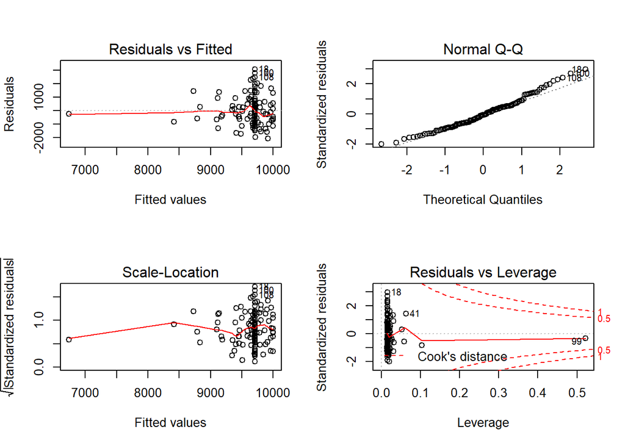

```r
creditreg <- lm(TotalCredit~ Maize.adoption + Treatment ,data=sdat)

par(mfrow=c(2,2))
plot(creditreg)
```

This looks better, but not great, specifically note the cone shaped residuals in the residuals vs fitted plot and the substantial trend deviations in the QQplot. Let’s test if our residuals are normal:

```r
shapiro.test(resid(creditreg) )
```

```
    Shapiro-Wilk normality test

data:  resid(creditreg)
W = 0.97653, p-value = 0.02111
```

P-value is below 0.1, indicating non-normality. Let’s add another few factors which we rationally expect to influence TotalCredit:

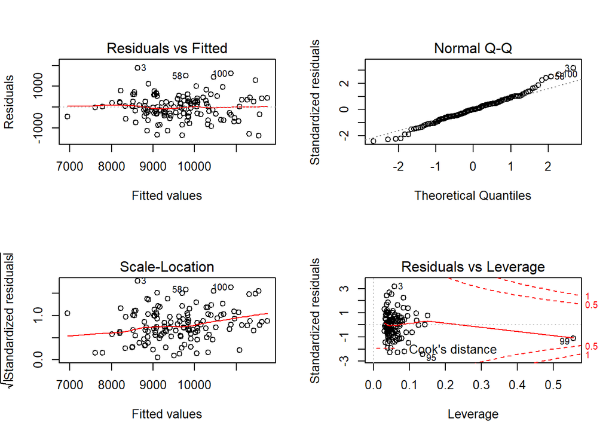

```r
creditreg2 <- lm(TotalCredit~ Maize.adoption + Maize.acres + Treatment + DistrictName + TotalEnrolledSeasons , data=sdat)

par(mfrow=c(2,2))
plot(creditreg2)
```

These are looking much healthier, note the Residuals vs Fitted, and Scale-Location graphs in particular. However our QQplot still looks a little weak:

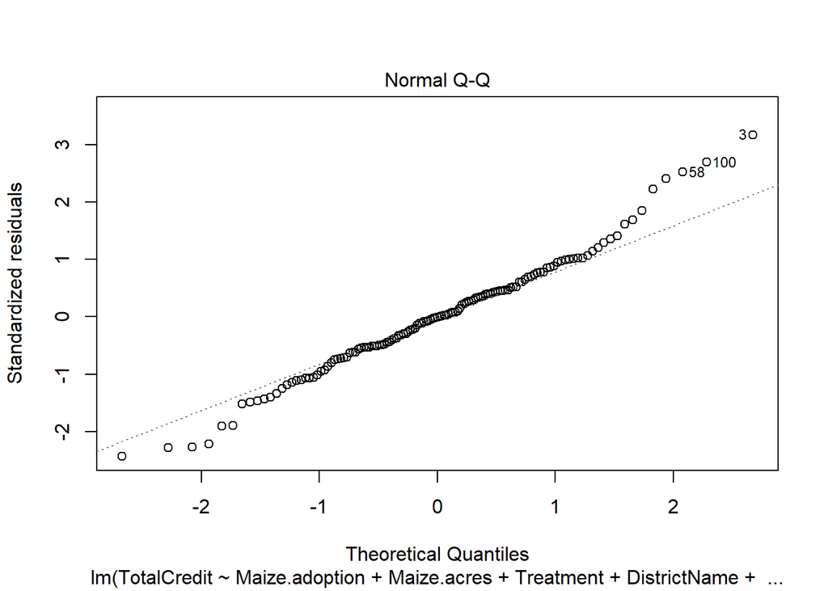

```r
plot(creditreg2, which=2)
```

I mentioned above that % (or fraction) data is a little tricky, this is because it is often censured at the lower or upper bound (i.e. it’s impossible to get a % lower than 0 or higher than 100 for maize adoption). We could run a [Tobit regression](http://www.karlin.mff.cuni.cz/~pesta/NMFM404/tobit.html) here (which will be covered in the AMP FAQ), alternatively we could make a transformation of our data.

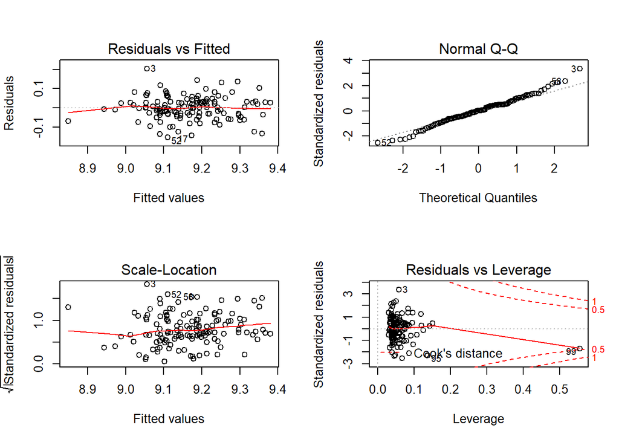

```r
sdat$logCredit = log(sdat$TotalCredit)


creditreg3 <- lm(logCredit~ Maize.adoption + Maize.acres + Treatment + DistrictName + TotalEnrolledSeasons , data=sdat)

par(mfrow=c(2,2))
plot(creditreg3)
```

```r
shapiro.test(resid(creditreg3))
```

```
    Shapiro-Wilk normality test

data:  resid(creditreg3)
W = 0.98966, p-value = 0.4262
```

Taking a $ln(TotalCredit)$ transformation clears up our remaining issues nicely and our QQplot is now close enough to normal (observe the reasonable Shapiro result).

However, remember our point from the theory section:

**transforming the y-variable has also changed the interpretation of our coefficients.**

The *only* time you can reasonably interpret these coefficients (without solving the associated differential equations) is when we have a natural-log transformation (*ln*). In the case of a *ln*(Y) variable, **our *coefficient * 100* will yield the percentage increase in Y from an increase of one unit in X.**

## 6.1 log(TotalCredit) regression

Let’s examine the results from our log transformed regression model:

```r
stargazer(creditreg3, type = "html",style="all", title="ln(Y) regression model",notes="", notes.append=FALSE,star.char="*", omit.table.layout = "na")
```

**ln(Y) regression model**

|  | *Dependent variable:* |
| --- | --- |
|  | logCredit |
| Maize.adoption | 0.091 |
|  | (0.100) |
|  | t = 0.910 |
|  | p = 0.365 |
| Maize.acres | 0.604*** |
|  | (0.082) |
|  | t = 7.402 |
|  | p = 0.000 |
| TreatmentT | -0.011 |
|  | (0.012) |
|  | t = -0.891 |
|  | p = 0.375 |
| DistrictNameKakamega (South) | -0.095*** |
|  | (0.018) |
|  | t = -5.161 |
|  | p = 0.00000 |
| DistrictNameMigori | 0.106*** |
|  | (0.016) |
|  | t = 6.460 |
|  | p = 0.000 |
| DistrictNameTinderet | 0.009 |
|  | (0.035) |
|  | t = 0.250 |
|  | p = 0.803 |
| TotalEnrolledSeasons | 0.027* |
|  | (0.014) |
|  | t = 1.957 |
|  | p = 0.053 |
| Constant | 8.711*** |
|  | (0.075) |
|  | t = 116.165 |
|  | p = 0.000 |
| Observations | 133 |
| R<sup>2</sup> | 0.710 |
| Adjusted R<sup>2</sup> | 0.693 |
| Residual Std. Error | 0.063 (df = 125) |
| F Statistic | 43.644*** (df = 7; 125) (p = 0.000) |

So interpreting the results above:

- Non significant factors (p > 0.05) include; maize adoption and **treatment**
- Significant factors: Maize acres, district, (borderline - total enrolled seasons)
- Maize acres; for every additional acre, the total credit taken increases by 60% (0.6*100).
- Being associated with Migori district leads to a11% increase in total credit.

## 6.2 Practical: Robust regressions

Finally, I want to quickly demonstrate the value of a robust regression. A robust regression is used when we have a few high-leverage points (remember point #99?) which might adversely effect our outcome (p-values, coefficients, etc). A robust regression will assign a lower weight to these points (vs. other points), ensuring that the model isn’t overly dependent on outliers. A robust regression isn’t required for the TotalCredit regression (as we have no points with high Cook’s distance), but let us run through it as an example anyway.

Rather than calling `lm` from base R, we will call `lmrob` from `robust` (see details [here](https://cran.r-project.org/web/packages/robust/robust.pdf)).

```r
library(robust, quietly = TRUE)
creditrob <-lmrob(formula = logCredit~ Maize.adoption + Maize.acres + Treatment + DistrictName + TotalEnrolledSeasons , data=sdat)
```

We will interpret the diagnostics similarly to the standard linear models above:

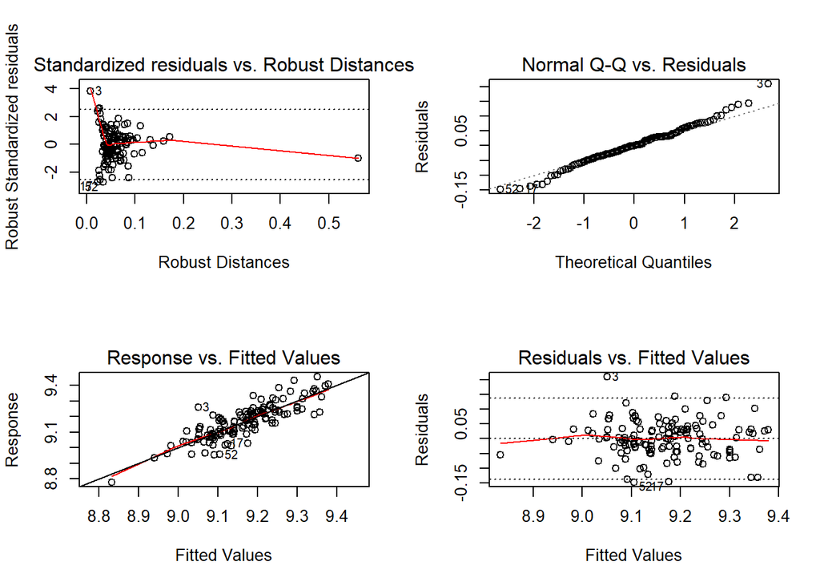

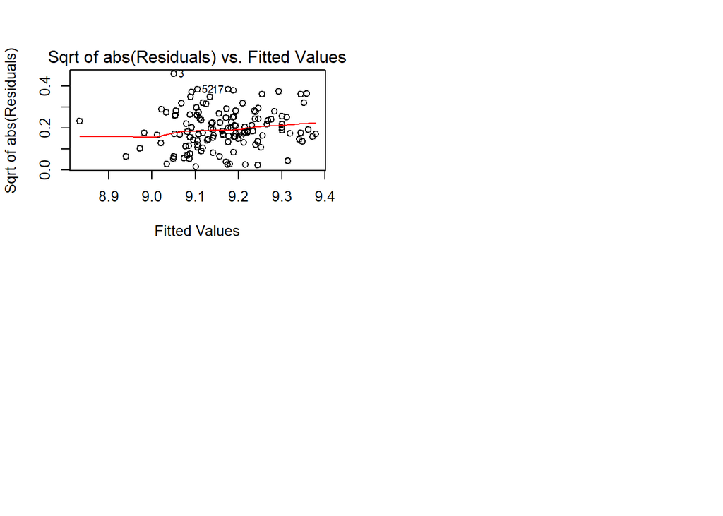

```r
par(mfrow=c(2,2))
plot(creditrob)
```

These plots indicate a model performing as expected, note that the `lmrob` library plots our fitted vs actual plot for us (and so is included above).

## 6.3 Practical: Comparing models

Let’s compare the models we have built thus far with the the `stargazer()` command:

```r
stargazer(creditreg, creditreg2, creditreg3, creditrob,type="html", title="Comparison of models", column.labels = c("Simple model","complex model", "log model","Robust log model"), dep.var.labels.include = FALSE, dep.var.caption = "Dependent variable: Total Credit ", digits=2)
```

**Comparison of models**

|  | Dependent variable: Total Credit |  |  |  |
| --- | --- | --- | --- | --- |
|  | *OLS* |  | *OLS* | *MM-type* |
|  |  |  |  | *linear* |
|  | Simple model | complex model | log model | Robust log model |
|  | (1) | (2) | (3) | (4) |
| Maize.adoption | 5,007.96*** | 92.35 | 0.09 | 0.11 |
|  | (1,282.17) | (977.58) | (0.10) | (0.10) |
| Maize.acres |  | 6,082.33*** | 0.60*** | 0.60*** |
|  |  | (793.88) | (0.08) | (0.09) |
| TreatmentT | -292.61 | -59.28 | -0.01 | -0.02 |
|  | (196.21) | (121.60) | (0.01) | (0.01) |
| DistrictNameKakamega (South) |  | -936.62*** | -0.09*** | -0.09*** |
|  |  | (178.24) | (0.02) | (0.02) |
| DistrictNameMigori |  | 1,009.89*** | 0.11*** | 0.11*** |
|  |  | (159.29) | (0.02) | (0.01) |
| DistrictNameTinderet |  | 42.45 | 0.01 | 0.01 |
|  |  | (337.05) | (0.03) | (0.04) |
| TotalEnrolledSeasons |  | 258.07* | 0.03* | 0.03* |
|  |  | (133.00) | (0.01) | (0.01) |
| Constant | 4,988.85*** | 5,849.94*** | 8.71*** | 8.69*** |
|  | (1,194.07) | (729.89) | (0.07) | (0.07) |
| Observations | 133 | 133 | 133 | 133 |
| R<sup>2</sup> | 0.11 | 0.70 | 0.71 | 0.74 |
| Adjusted R<sup>2</sup> | 0.09 | 0.69 | 0.69 | 0.72 |
| Residual Std. Error | 1,041.78 (df = 130) | 610.34 (df = 125) | 0.06 (df = 125) | 0.06 (df = 125) |
| F Statistic | 7.63*** (df = 2; 130) | 42.60*** (df = 7; 125) | 43.64*** (df = 7; 125) |  |
| *Note:* | p<0.1; p<0.05; p<0.01 |  |  |  |

This is a large table filled with information, but note that it is just providing the information we have seen before side-by-side. We can deduce a few things from this table:

- First, look at the `Adjusted R2` and `df` (degrees of freedom). We want the highest R2 with the fewest df (we will test this more robustly below). We can see that our right-most three models have a large gain in R2 with just a small loss of df. Of these three models, we have equal dfs, which means we can simply pick the model with the highest R2, which is the robust log regression.
- Secondly, note that the coefficients between the log model and robust log model are *very* similar. This is good (as we previously noted that a robust regression is likely unnecessary).
- Thirdly, note the broad agreement in *significance* between the three right-most models (this is also reassuring). Also note that the left-most model has wildly different results to the other models, this is because (as we know) that model violates many assumptions of linear modelling.

Once again, if we had only run the left-most model and left it there then we would have had very different conclusions to the other (far better) models.

We can directly compare two models with different degrees of freedom (i.e. different numbers of parameters) using the ANOVA command to understand whether the change in degrees of freedom (dfs) warrants the gain in accuracy. For example when comparing models 1 and 2 (the far left models):

```r
anova(creditreg,creditreg2)
```

```
Analysis of Variance Table

Model 1: TotalCredit ~ Maize.adoption + Treatment
Model 2: TotalCredit ~ Maize.adoption + Maize.acres + Treatment + DistrictName +
    TotalEnrolledSeasons
  Res.Df       RSS Df Sum of Sq     F    Pr(>F)
1    130 141089401
2    125  46564353  5  94525049 50.75 < 2.2e-16 ***
---
Signif. codes:  0 '***' 0.001 '**' 0.01 '*' 0.05 '.' 0.1 ' ' 1
```

We can see that model 2 is significantly better than model 1, and thus our addition of predictors is justified (models 2-4 all have equal dfs, so we can simply examine the unadjusted R-squared values alone). See the FAQ for more information on evaluating model fit.